# Replicating Ellis-Soto et al 2023, Nat Hum Beh

Martin Bulla & Peter Mikula created by Martin Bulla

2025-10-16 12:29:34

# General note

For the sake of reproducibility we stored the files from the [repository](https://doi.org/10.5281/zenodo.8052525) that acompanied original publication (Ellis-Soto, Chapman, and Locke 2023) in the folder [original_paper](https://github.com/MartinBulla/avian_FID_covid/tree/main/R/) folder (at the root project’s directory) with subfolders ‘Data’ and ‘Code’ (the latter two with the file structure as provided by the authors). We stored the additional data shared by the authors upon the request from The Institute for Replication in the ‘Data’ folder within the root project directory. Datasets that we recreated using the authors code `04_R4_uneven_biodiversity_data_2023.R` are at ‘Data/from_code_04’. Additional data recreated by us using our script rev_Dat_temporal_trend.R (which is the adjusted version of the authors’ `04_R4_uneven_biodiversity_data_2023.R`) are at ‘Data/MaPe’.

# TODO:

1. Decide whether we shall unify our terminology around:
- HOLC - sometimes we call it categories, sometimes grades
- polygons/neighbourhoods temporal trends per city & model ass

Scripts generating the outputs of this html are available upon clicking the `code` button at top right above each display item!

##### Code to load tools and data

```r
# 1. load or install packages
#  TODO:add model assumptions to the below models.
pkgs <- c("cowplot","data.table","dplyr", "forcats", "ggh4x","ggplot2","ggpp", "ggsci","ggtext", "grid", "kableExtra", "lme4", "mgcv", "patchwork", "readr", "scales", "sjPlot", "tibble", "tidyverse")  # list of packages

install_if_missing <- function(pkgs) {
  to_install <- setdiff(pkgs, rownames(installed.packages()))
  if (length(to_install)) install.packages(to_install, dependencies = TRUE)
  invisible(lapply(pkgs, require, character.only = TRUE))
}

install_if_missing(pkgs)

# 2. constants and functions
recreate_data = FALSE # use TRUE, if you wish to recreate the data, instead of loading them from .Data/

# Color palette for redlining
holc_pal <- c('#92BC6B' # green
              , '#92C7C9' # blue
              , '#E7DC6B' # yellow
              , '#E47D67' # red
)#, '#A9A9A9' # dark gray)

# Color palette for effect sizes
col_lz <- ggsci::pal_locuszoom("default")(7)

# add tag in a circle to a ggplot panel
tag_pos <- c(0.045, 0.94)   # x, y in panel [0..1]

offset_tag <- theme(
  plot.tag.location = "panel",
  plot.tag.position = tag_pos,
  plot.tag = element_text(hjust = 0.5, vjust = 0.5, size = 11)
)

circle_at_tag <- function(xy = tag_pos, r_pt = 6){
  annotation_custom(
    grob = grid::circleGrob(
      x = unit(xy[1], "npc"), y = unit(xy[2], "npc"),
      r = unit(r_pt, "pt"),
      gp = grid::gpar(fill = "white", col = "grey25", lwd = .6)
    ),
    xmin = -Inf, xmax = Inf, ymin = -Inf, ymax = Inf
  )
}

# function for quick plotting
plot_effects_holc <- function(
          model, data,
          year = "year", grade = "holc_grade",
          palette = NULL, n = 100, ylab = "Sampling density",
          title_model = TRUE, title_text = NULL, ver = 'v1',
          title_size = 9, title_colour = "grey40",
          save_png = TRUE, outdir = ".", filename = NULL,
          width = 9, height = 4.8, dpi = 300, timestamp = FALSE
  ) {

     safe_slug <- function(x, max = 120) {
        x <- tolower(x)
        x <- gsub("\\s+", " ", x)
        x <- gsub("[^a-z0-9]+", "-", x)
        x <- gsub("(^-+|-+$)", "", x)
        substr(x, 1, max)
    }

     xr <- seq(min(data[[year]], na.rm = TRUE),
          max(data[[year]], na.rm = TRUE), length.out = n)

     eff <- suppressWarnings(effects::Effect(c(year, grade), model,
                         xlevels = setNames(list(xr), year)))

     pp <- as.data.frame(eff)
     pp[[grade]] <- factor(pp[[grade]])
     pp$fit_o   <- exp(pp$fit)
     pp$lower_o <- exp(pp$lower)
     pp$upper_o <- exp(pp$upper)

     # integer 5-year ticks within data range
      yr_rng   <- range(pp[[year]], na.rm = TRUE)
      yr_breaks <- seq(ceiling(yr_rng[1]/5)*5, floor(yr_rng[2]/5)*5, by = 5)

     lev <- levels(pp[[grade]])
     if (is.null(palette)) {
     palette <- setNames(scales::hue_pal()(length(lev)), lev)
     } else if (is.null(names(palette)) && length(palette) == length(lev)) {
     names(palette) <- lev
     }

     p1 =
     ggplot(pp, aes(year, fit_o, color = holc_grade, fill = holc_grade)) +
     geom_ribbon(aes(ymin = lower_o, ymax = upper_o), alpha = .15, colour = NA) +
     geom_line() +
     scale_color_manual(values = holc_pal, name = 'HOLC grade')+
     scale_fill_manual(values = holc_pal, name = 'HOLC grade')+
     scale_x_continuous(breaks = yr_breaks,
                     labels = scales::number_format(accuracy = 1),
                     minor_breaks = NULL) +
     labs(x = "Year", y = ylab, subtitle = 'ln-scale') +
     scale_y_continuous(trans='log')+
     theme_light()+
     theme( plot.subtitle = element_text(size = 10, colour = "grey40"))

     p2 =
     ggplot(pp, aes(year, fit_o, color = holc_grade, fill = holc_grade)) +
     geom_ribbon(aes(ymin = lower_o, ymax = upper_o), alpha = .15, colour = NA) +
     geom_line() +
     scale_color_manual(values = palette, name = 'HOLC grade')+
     scale_fill_manual(values = palette, name = 'HOLC grade')+
     scale_x_continuous(breaks = yr_breaks,
                     labels = scales::number_format(accuracy = 1),
                     minor_breaks = NULL) +
     labs(x = "Year", y = ylab, subtitle = 'original-scale') +
     theme_light()+
     theme( plot.subtitle = element_text(size = 10, colour = "grey40"))

     p2_ <- p2 + theme(axis.title.y = element_blank())

     title_str <- if (!is.null(title_text)) title_text else
        if (isTRUE(title_model))
            paste0("Model: ",
                gsub("\\s+", " ",
                        paste(trimws(deparse(formula(model), width.cutoff = 500)),
                            collapse = " ")))
        else NULL

      g <- (p1 + p2_) + patchwork::plot_layout(guides = "collect", axis_titles = "collect")

      if (!is.null(title_str)) {
        g <- g + patchwork::plot_annotation(
          title = title_str,
          theme = ggplot2::theme(
            plot.title = element_text(
              size = title_size,
              colour = title_colour,
              hjust = 0))
        )
      }

     # Optional save (timestamp at END)
     if (isTRUE(save_png)) {
      if (is.null(filename)) {
        stamp <- if (timestamp) paste0("__", format(Sys.time(), "%Y%m%d-%H%M")) else ""
        fname <- paste0(safe_slug(title_str), stamp, "__", ver, ".png")
       } else {
        fname <- filename
       }
      dir.create(outdir, showWarnings = FALSE, recursive = TRUE)
      ggplot2::ggsave(file.path(outdir, fname), plot = g,
                    width = width, height = height, dpi = dpi, bg = "white")
      message("Saved: ", file.path(outdir, fname))
     }

     g
}

# function to extract fixed effects from lmer
ext_fixef <- function(m) {
  mf  <- model.frame(m)
  sdy <- as.numeric(attr(mf[["scale(year)"]], "scaled:scale"))

  fe <- fixef(m); V <- as.matrix(vcov(m)); se <- sqrt(diag(V)); z <- qnorm(0.975)
  nm <- names(fe); pick <- function(p) grep(p, nm, value = TRUE)

  ints_n <- pick("^holc_grade[^:]+$")
  slps_n <- pick("^holc_grade[^:]+:scale\\(year\\)$")

  ints <- tibble(
    type = "intercept",
    holc_grade = sub("^holc_grade","", ints_n),
    estimate = fe[ints_n],
    std.error = se[ints_n],
    conf.low = estimate - z*std.error,
    conf.high = estimate + z*std.error
  )
```

```r
  slps <- tibble(
    type = "slope_per_SDyear",
    holc_grade = sub(":.*","", sub("^holc_grade","", slps_n)),
    estimate = fe[slps_n],
    std.error = se[slps_n],
    conf.low = estimate - z*std.error,
    conf.high = estimate + z*std.error
  ) |>
    mutate( # convert to per-year on the same log scale
      estimate_per_year = estimate / sdy,
      conf.low_per_year = conf.low / sdy,
      conf.high_per_year= conf.high / sdy
    )

  bind_rows(ints, slps)
}

# function to extract fixed effects from lm
ext_fixef_lm <- function(m) {
  mf  <- model.frame(m)
  sdy <- as.numeric(attr(mf[["scale(year)"]], "scaled:scale"))

  fe <- coef(m); V <- as.matrix(vcov(m)); se <- sqrt(diag(V)); z <- qnorm(0.975)
  nm <- names(fe)

  ints_n <- nm[grepl("^holc_grade", nm) & !grepl(":", nm)]
  slps_n <- nm[grepl("^holc_grade", nm) & grepl(":.*scale\\(year\\)", nm)]
  base_slope_n <- nm[grepl("^scale\\(year\\)$", nm)]

  lvls <- levels(mf$holc_grade)

  lvl_from <- function(x) {
    x <- sub("^holc_grade[_]?", "", x)
    x <- sub(":.*$", "", x)
    if (x %in% lvls) return(x)
    # patterns like DA/DB/DC/DD with ref first
    if (nchar(x) == 2 && substr(x,1,1) == lvls[1]) {
      y <- substr(x,2,2)
      if (y %in% lvls) return(y)
      if (x == paste0(lvls[1], lvls[1])) return(lvls[1])  # DD -> D
    }
    x
  }

  ints <- tibble::tibble(
    type       = "intercept",
    holc_grade = vapply(ints_n, lvl_from, character(1)),
    estimate   = fe[ints_n],
    std.error  = se[ints_n],
    conf.low   = estimate - z * std.error,
    conf.high  = estimate + z * std.error
  )

  slps_core <- tibble::tibble(
    type       = "slope_per_SDyear",
    holc_grade = vapply(sub(":.*$", "", slps_n), lvl_from, character(1)),
    estimate   = fe[slps_n],
    std.error  = se[slps_n],
    conf.low   = estimate - z * std.error,
    conf.high  = estimate + z * std.error
  )

  ref_level <- lvls[1]
  if (length(base_slope_n) == 1) {
    base_row <- tibble::tibble(
      type       = "slope_per_SDyear",
      holc_grade = ref_level,
      estimate   = fe[base_slope_n],
      std.error  = se[base_slope_n],
      conf.low   = fe[base_slope_n] - z * se[base_slope_n],
      conf.high  = fe[base_slope_n] + z * se[base_slope_n]
    )
    slps <- dplyr::bind_rows(slps_core, base_row)
  } else {
    slps <- slps_core
  }

  slps <- slps |>
    dplyr::mutate(
      estimate_per_year  = estimate / sdy,
      conf.low_per_year  = conf.low / sdy,
      conf.high_per_year = conf.high / sdy
    ) |>
    dplyr::arrange(factor(holc_grade, lvls))

  dplyr::bind_rows(
    ints |> dplyr::arrange(factor(holc_grade, lvls)),
    slps
  )
}

# function to extract lmer fixed effects as difference from holc D
ext_fixef_D <- function(m) {
  mf  <- model.frame(m)
  sdy <- as.numeric(attr(mf[["scale(year)"]], "scaled:scale"))

  fe <- fixef(m); V <- as.matrix(vcov(m)); se <- sqrt(diag(V)); z <- qnorm(0.975)
  nm <- names(fe)

  ints_n <- grep("^holc_grade_D[^:]+$",
    nm, perl = TRUE, value = TRUE
  )
  slps_n <- grep(
    "^(?:holc_grade_D[^:]+:scale\\(year\\)|scale\\(year\\):holc_grade_D[^:]+)$",
    nm, perl = TRUE, value = TRUE
  )

  # extract the level letter (A/B/C)
  lev <- function(term) sub(".*holc_grade_D([^:]+).*", "\\1", term)

  ints <- tibble(
    type = "intercept",
    holc_grade = lev(ints_n),
    estimate = fe[ints_n],
    std.error = se[ints_n],
    conf.low = estimate - z*std.error,
    conf.high = estimate + z*std.error
  )

  slps <- tibble(
    type = "slope_per_SDyear",
    holc_grade = lev(slps_n),
    estimate = fe[slps_n],
    std.error = se[slps_n],
    conf.low = estimate - z*std.error,
    conf.high = estimate + z*std.error
  ) |>
    dplyr::mutate( # convert to per-year on the same log scale
      estimate_per_year = estimate / sdy,
      conf.low_per_year = conf.low / sdy,
      conf.high_per_year= conf.high / sdy
    )

  dplyr::bind_rows(ints, slps)
}

# function to extract fixed effects from lm objects (D baseline; matches lmer extractor)
ext_fixef_D_lm <- function(m) {
  mf  <- model.frame(m)
  sdy <- as.numeric(attr(mf[["scale(year)"]], "scaled:scale"))
  fe  <- coef(m); V <- as.matrix(vcov(m)); se <- sqrt(diag(V)); z <- qnorm(0.975)
  nm  <- names(fe)
  ints_n <- grep("^holc_grade_D[^:]+$", nm, perl = TRUE, value = TRUE)
  slps_n <- grep("^(?:holc_grade_D[^:]+:scale\\(year\\)|scale\\(year\\):holc_grade_D[^:]+)$",
                 nm, perl = TRUE, value = TRUE)
  lev <- function(term) sub(".*holc_grade_D([^:]+).*", "\\1", term)

  ints <- tibble(
    type = "intercept", holc_grade = lev(ints_n),
    estimate = fe[ints_n], std.error = se[ints_n]
  ) |>
    mutate(conf.low = estimate - z*std.error,
           conf.high = estimate + z*std.error)

  slps <- tibble(
    type = "slope_per_SDyear", holc_grade = lev(slps_n),
    estimate = fe[slps_n], std.error = se[slps_n]
  ) |>
    mutate(conf.low = estimate - z*std.error,
           conf.high = estimate + z*std.error,
           estimate_per_year = estimate / sdy,
           conf.low_per_year = conf.low / sdy,
           conf.high_per_year= conf.high / sdy)

  bind_rows(ints, slps)
}

# 3a. load authors' data for HOLC comparison (uses code from the authors' 05_paper_1_analyses_R4.Rmd)
  holc <- read_csv('original_paper/Data/Biodiv_Greeness_Social/soc_dem_max_2022_03_12 17_31_11.csv'
                   , col_select = c(id : area_holc_km2
                                    , holc_tot_pop
                                    , msa_GEOID : msa_total_popE
                                    , msa_gini))
  birds_records <-
    read_csv('original_paper/Data/Biodiv_Greeness_Social/R1_biodiv_sum_bird_obs_by_holc_id_1933_2022.csv') |>
    mutate(id = str_remove(id, '_Aves_all_observations')) |>
    select(id, records = N_samples)

  birds_completeness <-
    read_csv('original_paper/Data/Biodiv_Greeness_Social/bird_completeness_HOLC_cities_2022_R1.csv') |>
    select(id, completeness = Completeness) |>
    tidylog::mutate(id = ifelse(id == 'VA_Roanoke_B2\\r\\n2_B_9289', 'VA_Roanoke_B2\r\n2_B_9289', id))
```

```r
  birds_source <-
    read_csv('original_paper/Data/Biodiv_Greeness_Social/R1_biodiv_col_code_by_holc_id_2000_2020.csv') |>
    mutate(id = str_remove(id, '_Aves_all_observations')) |>
    select(id, records = N_samples, type = Collection_code) |>
    pivot_wider(id_cols = id, names_from = type, values_from = records)

  clim <- read_csv('original_paper/Data/Biodiv_Greeness_Social/climatic_data_cities.csv'
                   , col_select = c(  -'...1'
                                    , mean_temp_c = mean_temp
                                    , mean_precip_mm = mean_precip)
                   )
  green <- read_csv('original_paper/Data/Biodiv_Greeness_Social/NDVI_unique_ID_updated.csv') %>%
        mutate(ndvi = ifelse(is.na(ndvi), median(.$ndvi, na.rm = TRUE), ndvi)) |> # interpolated missing
        select(id, ndvi)

  pad <- read_csv('Data/NDVI_PAD_unique_ID.csv'#'original_paper/Data/Biodiv_Greeness_Social/NDVI_PAD_unique_ID.csv'
                 , col_select = c(id, pct_pa = percent_pa))
  # combine
  comb <-
    left_join(holc, birds_records, by = 'id') |> # adds bird biodiversity
    left_join(birds_completeness, by = 'id') |> # adds bird completeness
    left_join(birds_source, by = 'id') |> # adds in sampling by source
    left_join(clim, by = 'city') |> # adds temp and precip
    left_join(green, by = 'id') |> # adds green
    left_join(pad, by = 'id') |> # adds protected areas
    mutate(
        pop_per_km           = ifelse(is.na(holc_tot_pop), 0, holc_tot_pop / area_holc_km2)
        , sampling_density     = records / area_holc_km2
        , sampling_density_log = log(sampling_density)
        , completeness_log     = log(completeness)) |>
    relocate(sampling_density, sampling_density_log, completeness, completeness_log,
            .before = completeness)

  h = data.table(comb)
  h=h[!holc_grade%in%'E']

  # additional variables
  h[, sample_binary := ifelse(is.na(sampling_density_log), 0, 1)]

  h[holc_grade%in%'A', holc_grade_num:=1]
  h[holc_grade%in%'C', holc_grade_num:=2]
  h[holc_grade%in%'B', holc_grade_num:=3]
  h[holc_grade%in%'D', holc_grade_num:=4]

  # add city lat lon
  latlon = fread('Data/MaPe_cities_coordinates.txt')
  h = merge(h, latlon, all.x =TRUE)

# 3b. load authors' temporal data
t = fread('original_paper/Data/Biodiv_Greeness_Social/R1_biodiv_trend_by_time_holc_id_1933_2022.csv') #tt = fread('Data/from_script_04/R1_biodiv_trend_by_time_holc_id_1933_2022.csv')
# names(temporal_trend) <- c('Year','holc_grade','Type','holc_polygon_id', 'Sum')
names(t) <- c('year','holc_grade', 'Sum')

t = t[holc_grade != 'E'] #d = data.table(temporal_trend)
tt = t[, .(n_obs = sum(Sum)), by = list(year, holc_grade)]
tt = tt[order(holc_grade,year)]

# add area per holc grade (as the authors used two ways to calculate this, we test both, but then use only the (b) as that seems to be the one eventually used)
  # a)
  holc_a <- fread('original_paper/Data/Biodiv_Greeness_Social/soc_dem_max_2022_03_12 17_31_11.csv')

  holc_area_sum_a = holc_a[, list(sum_area_holc_km2 = sum(area_holc_km2)), holc_grade]
  holc_area_sum_a_dt = data.table(holc_area_sum_a)
    # gives
      #  holc_grade: chr [1:4] "A" "B" "C" "D"
      #  sum_area_holc_km2  : num [1:4] 1279 2712 5179 3280

  # b) copy of the L54-65 of 04_R4_uneven_biodiversity_data_2023.R, with MaPe changed folder path
  holc_b <- suppressWarnings(sf::st_read('Data/holc_ad_data.shp', quiet = TRUE) %>% #MaPe changed folder path
      sf::st_cast('POLYGON') %>% # IMPORTANT
      dplyr::filter(!sf::st_is_empty(.)) %>%
      sf::st_make_valid(.) %>%
      tibble::rowid_to_column() %>%
      dplyr::mutate(  id = paste(state, city, holc_id, holc_grade, rowid, sep = '_')
                      , city_state = paste0(city, ', ', state)
                      , area_holc_km2 = as.double(sf::st_area(.) / 1e+6)) %>%
      dplyr::select(id, state, city, holc_id, holc_grade, city_state, area_holc_km2) )

    # Calculate the total area of holc polygons
    holc_area_sum_b <-  holc_b %>% dplyr::select(city, holc_grade, area_holc_km2) %>% dplyr::group_by(holc_grade) %>% dplyr::summarise(sum_area_holc_km2 = sum(area_holc_km2)) %>% dplyr::filter(holc_grade != 'E')  %>% as_tibble() %>% dplyr::select(-geometry)
    # gives
      #  holc_grade: chr [1:4] "A" "B" "C" "D"
      #  sum_area_holc_km2  : num [1:4] 1282 2948 4365 2689
   holc_area_sum_b_dt = data.table(holc_area_sum_b)

tta = merge(tt,holc_area_sum_a_dt, all.x = TRUE)
ttb = merge(tt,holc_area_sum_b_dt, all.x = TRUE)

# sampling density
tta[, sampling_density := n_obs/sum_area_holc_km2]
ttb[, sampling_density := n_obs/sum_area_holc_km2]
tta[, sampling_density_b :=ttb$sampling_density]

#ggplot(tta, aes(x = sampling_density, y = sampling_density_b)) +
#  geom_abline(slope = 1, intercept = 0, linetype = "dotted", col = 'red') +
#  geom_point() +
#  facet_wrap(~holc_grade) +
#  coord_equal(expand = FALSE)

# adjust contrasts - ensure treatment coding with D as baseline
options(contrasts = c("contr.treatment", "contr.poly"))
ttb[, holc_grade_D := factor(holc_grade, levels = c("D","B","C","A"))]
tt00 = ttb[year >= 2000 & year <= 2020]
tt10 = tt00[year >= 2010]

# estimate 2000 - 2020 A/D disparity
dispar = round((((ttb[year%in%c(2020) &  holc_grade%in%c('A'), sampling_density] / ttb[year%in%c(2020) &  holc_grade%in%c('D'), sampling_density])/(ttb[year%in%c(2000) &  holc_grade%in%c('A'), sampling_density]/ ttb[year%in%c(2000) &  holc_grade%in%c('D'), sampling_density]))-1)*100, 1)

# 4. load temporal data for year, category, neighbourhood (polygon) generated by us

if(recreate_data==TRUE){
  source('R/rev_Dat_temporal_trend.R')
}else{
  d = fread('Data/MaPe/mape_num-of-obs_by_holc_id_year.csv')
  b = fread('Data/MaPe/mape_num-of-obs_by_holc_id_year_data-source.csv')
}

d = d[!holc_grade%in%c('E')]
d = d[!area_holc_km2%in%0] # remove polygons with zero area

# Ensure treatment coding with D as baseline (IMPORTANT)
options(contrasts = c("contr.treatment", "contr.poly"))
d[, holc_grade_D := factor(holc_grade, levels = c("D","B","C","A"))]
```

```r
# sampling density
d[, sampling_density:=sum_bird_obs/area_holc_km2]

# subset
d00 = d[year >= 2000 & year <= 2020]
d10 = d[year >= 2010 & year <= 2020] # save(file = 'Data/Dat_temporal-trend.Rdata', d00, d10)

# create median per year and HOLC
d_med = d[, .(sampling_density_med = median(sampling_density)), by = .(year, holc_grade)]
#ggplot(d_med, aes(x = sampling_density_med)) +  geom_density()

# aggregate temporal data per year and HOLC (as the authors have done)
dd = d[, .(sum_bird_obs = sum(sum_bird_obs)), by = .(year, holc_grade)] # we have initially used the sum_km2 = sum(area_holc_km2) as well, but because our data are missing neighbourhoods that had no ID to link them with neighbourhood area and hence has fewer sampled neighbourhoods and hence smaller area, for consistency with the authors' values, we use their overall area per HOLC grade.

dd = merge(dd,holc_area_sum_b_dt, all.x = TRUE)

# sampling density
dd[, sampling_density := sum_bird_obs/sum_area_holc_km2]

# disparity in ration (meaning of it unclear given the similarity in 2000)
dispar2 = round((((dd[year%in%c(2020) &  holc_grade%in%c('A'), sampling_density] / dd[year%in%c(2020) &  holc_grade%in%c('D'), sampling_density])/(dd[year%in%c(2000) &  holc_grade%in%c('A'), sampling_density]/
 dd[year%in%c(2000) &  holc_grade%in%c('D'), sampling_density]))-1)*100, 1) #Using the dataset per year, HOLC grade and neighbourhoods generated yet a different percentage.
```

# 1. HOLC grade differences

The authors investigated how HOLC grades differ in bird sampling using three response variables:  
A. A neighbourhoods sampled or not (binary outcome).  
B. Sampling density (km²).  
C. Completeness of sampling.  
Accordingly, three sets the authors fitted three sets of models. However, the Methods are ambiguous about the number of models fitted, as it is unclear whether the various predictors were added one by one or at once, as well as about the variables used. Moreover, the described model structures do not seem to fit with the one presented in the script `05_paper_1_analyses_R4.Rmd`. Specifically, the authors note “The simplest null model (intercept only) was fit and fixed effects for HOLC (primary variable of interest) were added. Next, the following terms were added: metropolitan statistical area (MSA) as a random intercept, HOLC grade as a random slope, and fixed effects for NDVI, percent open space and population density as random slopes within HOLC-defined city for mean temperature and precipitation (climate) interaction.” (p. 1875)(Ellis-Soto, Chapman, and Locke 2023). This description makes (i) unclear what variables were fitted as fixed or random slopes and whehter the terms were added sequentially or into a single complex model. Importantly, the authors do not describe response specific models; hence, we assumed that they fitted the same model structure to all three response variables.  
**First**, we show how we interpret the above model specification showing fixed effects and random effects of the model with random effects being enclosed in paranthesis with the term in front of `|` representing random slope, the term after `|` representing random intercepts, explicitly nested terms connected by `/` and interaction by `:`: 1. ~ 1 (intercept only model)  
2. ~ HOLC grade 3. ~ HOLC grade + (1 | metropolitan area) 4. ~ HOLC grade + (HOLC grade | metropolitan are) 5. ~ HOLC grade + other predictors + (HOLC grade | metropolitan area)  
6. ~ HOLC grade + other predictors + (HOLC grade | metropolitan area) + (HOLC grade | metropolitan area) + (temperature : precipitation | city ) Where (5) and (6) possibly represent multiple models where each predictor (NDVI, open space (%), population density (per km²), and perhaps mean temperature and precipitation) was added one by one.  
Note that the authors also do not describe any check of model assumptions and we found none in theirs scripts.  
**Second**, the script revealed that, e.g. for neighbourhoods sampled (binary respons), three models seemed to have been fitted. Model 3 and 4 described above and a complex model, not described in the Methods:  
7. ~ HOLC grade + NDVI + open space + population density + (1 + HOLC grade + msa_gini | metropolitan area) + (1 + temperature : precipitation | city)  
This model resambles a model described in the Method, i.e. model (6) above, but with essential nuance: two random slopes are fitted within metropolitan area, one of which, `msa_gini`, is nowhere defined. We speculate that `msa_gini` represents Gini index of household income inequality at the level of metropolitan area (having same n). Given that has the same number of levels as metropolitan are, `msa_gini` cannot be fitted as random slope within metropolitan area, i.e. the model is misspecified.

The model sets for the other two responses suffer from similar issues. For example, `msa_medhhincE` random slope within metropolitan area suffers from the same issues as `msa_gini`, i.e. is not defined in the main text and thus its meaning is unclear, and has similar (less) number of unique values as the metropolitan area within which it was fitted, leading to model misspecification. Similarly, interaction of temperature and precipitation as random slope within city has only within city-specific values (combinations).

We believe that the authors should have fitted one complex model that is controlled for all discussed variables as well as non-indepence of data points. Their data with n around 9,000 neighbourhoods and clear data structure allows that. If in doubt, fitting a simpler model and comparing its estimates witht the complex one would suffice.

Here, we respecified the model set for each response and compared the model estimates. We include plausible models from the authors’ set and included further models either with HOLC grade as a single fixed effect (simple models) or including also all other continues control variables (discussed by the authors) as fixed effects (NDVI, open space (%), population density (per km²), mean temperature and mean precipitation; full model). For our simple and full modle we varied the random structure (i) to mirror the authors’ logic, but using only discussed and meaningful variables (e.g. excluding random slopes with same number of levels as the corresponding random intercept), and (ii) to account for non-independence of data points. The sets included the following models where those with random intercept of `metropolitan area` indicate the authors’ ones, and those with random intercept of `city` ours. Note that we use city (unique across the dataset), instead of the metropolitan area (as city has more levels).  
1. ~ HOLC grade + (1 | metropolitan area)  
2. ~ HOLC grade + (1 | city)  
3. ~ HOLC grade + (1 + HOLC grade | metropolitan area)  
4. ~ HOLC grade + (HOLC grade | city)  
5. ~ HOLC grade + (HOLC grade numeric | city)  
6. ~ HOLC grade + NDVI + protected area % + population density + (1 + HOLC grade | metropoly)  
7. ~ HOLC grade + NDVI + protected area % + population density + temperature * precipitation + (HOLC grade | city)  
8. ~ HOLC grade + NDVI + protected area + population density + temperature * precipitation + (HOLC grade numeric | city)  
9. ~ HOLC grade + NDVI + protected area % + population density + temperature * precipitation + (1|state) + (HOLC grade | city)

Note that for the neighbourhoods samples authors did not use the model (6) and hence we have not specified it. Also, we have attempted a model with random intercepts of state, metropolitan area and city, but those models converged poorly (similar levels for metropolitan are adn city). Our go for model is the number 9 because it controls for the variables intended by the authors and best addresses the non-independence of data points.

In the coming sections A, B, C we compare the HOLC grade estimates from the various models for each response variable.

## A. Sampled or not

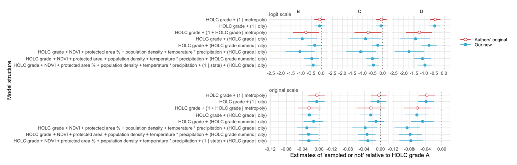

```r
  # binary models

    # specified by authors (second one fails to converge)
    samp_d_binary_holc = lme4::glmer(sample_binary ~ holc_grade +
        (1 | msa_NAME),
        data = h,
        family = binomial(link = "logit"))

    samp_d_binary_holc_rirs = lme4::glmer(sample_binary ~ holc_grade +
        (holc_grade | msa_NAME),
        data = h,
        family = binomial(link = "logit"))

    # specified by us
    m0 = lme4::glmer(sample_binary ~ holc_grade +
        (1 | city_state),
        data = h,
        family = binomial(link = "logit"),
        control = glmerControl(optimizer = "bobyqa",
                            optCtrl = list(maxfun = 2e5))
        )

    m1= lme4::glmer(sample_binary ~ holc_grade +
        (holc_grade | city_state),
        data = h,
        family = binomial(link = "logit"),
        control = glmerControl(optimizer = "bobyqa",
                            optCtrl = list(maxfun = 2e5))
        )

    m2= lme4::glmer(sample_binary ~ holc_grade +
        (holc_grade_num | city_state),
        data = h,
        family = binomial(link = "logit"),
        control = glmerControl(optimizer = "bobyqa",
                            optCtrl = list(maxfun = 2e5))
        )
    m1p= lme4::glmer(sample_binary ~ holc_grade + scale(ndvi) + scale(pct_pa) + scale(pop_per_km) + scale(mean_temp_c)*scale(mean_precip_mm) +
        (holc_grade | city_state),
        data = h,
        family = binomial(link = "logit"),
        control = glmerControl(optimizer = "bobyqa",
                            optCtrl = list(maxfun = 2e5))
        )

    m2p= lme4::glmer(sample_binary ~ holc_grade + scale(ndvi) + scale(pct_pa) + scale(pop_per_km) + scale(mean_temp_c)*scale(mean_precip_mm) +
        (holc_grade_num | city_state),
        data = h,
        family = binomial(link = "logit"),
        control = glmerControl(optimizer = "bobyqa",
                            optCtrl = list(maxfun = 2e5)))

    m3p= lme4::glmer(sample_binary ~ holc_grade +
        scale(ndvi) + scale(pct_pa) + scale(pop_per_km) + scale(mean_temp_c)*scale(mean_precip_mm) +
        (1|state) + (holc_grade_num | city_state),
        data = h,
        family = binomial(link = "logit"),
        control = glmerControl(optimizer = "bobyqa",
                            optCtrl = list(maxfun = 2e5)))
  # PLOT for logit
    # add models to a list
    models_A<- list(
    samp_d_binary_holc      = samp_d_binary_holc,
    samp_d_binary_holc_rirs = samp_d_binary_holc_rirs,
    m0       = m0,
    m1       = m1,
    m2       = m2,
    m1p      = m1p,
    m2p      = m2p,
    m3p      = m3p
    )

    # model labels
    model_labels_A <- c(
    samp_d_binary_holc      = "HOLC grade + (1 | metropoly)",
    samp_d_binary_holc_rirs    = "HOLC grade + (1 + HOLC grade | metropoly)",
    m0       = "HOLC grade + (1 | city)",
    m1       = "HOLC grade + (HOLC grade | city)",
    m2       = "HOLC grade + (HOLC grade numeric | city)",
    m1p      = "HOLC grade + NDVI + protected area % + population density + temperature * precipitation + (HOLC grade | city)",
    m2p      = "HOLC grade + NDVI + protected area + population density + temperature * precipitation + (HOLC grade numeric | city)",
    m3p   = "HOLC grade + NDVI + protected area % + population density + temperature * precipitation + (1 | state) + (HOLC grade | city)"
    )

    # sort models
    models_A_order <- c(
        "HOLC grade + (1 | metropoly)",
        "HOLC grade + (1 | city)",
        "HOLC grade + (1 + HOLC grade | metropoly)",
        "HOLC grade + (HOLC grade | city)",
        "HOLC grade + (HOLC grade numeric | city)",
        "HOLC grade + NDVI + protected area % + population density + temperature * precipitation + (HOLC grade | city)",
        "HOLC grade + NDVI + protected area + population density + temperature * precipitation + (HOLC grade numeric | city)",
        "HOLC grade + NDVI + protected area % + population density + temperature * precipitation + (1 | state) + (HOLC grade | city)"
    )

    # extract
    coef_df_A <- purrr::imap_dfr(models_A, ~ ext_fixef(.x) |> dplyr::mutate(model=.y))

    coef_df_A <- coef_df_A %>%
    mutate(model_label = factor(model_labels_A[model], levels = models_A_order)) %>% data.table()

    # distinquish original models from our alternative ones
    coef_df_A <- coef_df_A %>%
    mutate(
        model_group = ifelse(grepl("^samp", model), "Authors' original", "Our new"),
        model_label = model_labels_A[model]
    )

    coef_df_A <- coef_df_A %>%
    mutate(model_label = factor(model_label, levels = models_A_order))

    red_ = "#D43F3AFF" # ggsci::pal_locuszoom()(5)
    blue_ =  "#46B8DAFF"

    # plot
    A1 =
    ggplot(coef_df_A, aes(x = estimate, y = fct_rev(model_label))) +
    geom_errorbar(aes(xmin = conf.low, xmax = conf.high,
        color = model_group),
        position = position_dodge(width = 0.6), height = 0) +
    geom_point(aes(color = model_group, fill = model_group), position = position_dodge(width = 0.6), size = 1.5, shape =21) +
    geom_vline(xintercept = 0, linetype = "dotted", color = "grey40") +
    facet_wrap(~ holc_grade) +
    scale_color_manual(values = c("#D43F3AFF","#46B8DAFF")) +
    scale_fill_manual(values = c("white","#46B8DAFF")) +
    #scale_shape_manual(values = c(21, 16), guide = "none") +  # shapes fixed, no shape legend
    theme_minimal(base_size = 8) +
    labs(
        x = "",
        y = "Model structure",
        color = NULL,
        fill = NULL,
        subtitle = 'logit scale'
    ) +
    theme(
        legend.key.height = unit(0.25, "cm"),  # reduce vertical spacing between items
        plot.subtitle = element_text(size = 7, colour = "grey40", margin = margin(b=-14))
        )#; ggsave('Output/Fig_r1_Sampled01_v2.jpg', width = 25, height = 5, units = 'cm')

  # gaussian
    # as specified abvoe by the authors
    samp_m0_g = lmer(sample_binary ~ holc_grade +
        (1 | msa_NAME),
        data = h)

    samp_m1_g= lmer(sample_binary ~ holc_grade +
        (holc_grade | msa_NAME),
        data = h,
        control = lmerControl(optimizer = "bobyqa",
                            optCtrl = list(maxfun = 2e5)))

    # specified by us
    m0_g = lmer(sample_binary ~ holc_grade +
        (1 | city_state),
        data = h)

    m1_g= lmer(sample_binary ~ holc_grade +
        (holc_grade | city_state),
        data = h,
        control = lmerControl(optimizer = "bobyqa",
                            optCtrl = list(maxfun = 2e5)))

    m2_g= lmer(sample_binary ~ holc_grade +
        (holc_grade_num | city_state),
        data = h,
        control = lmerControl(optimizer = "bobyqa",
                            optCtrl = list(maxfun = 2e5)))

    m1p_g= lmer(sample_binary ~ holc_grade + scale(ndvi) + scale(pct_pa) + scale(pop_per_km) + scale(mean_temp_c)*scale(mean_precip_mm) +
        (holc_grade | city_state),
        data = h,
        control = lmerControl(optimizer = "bobyqa",
                            optCtrl = list(maxfun = 2e5))
        )

    m2p_g= lmer(sample_binary ~ holc_grade + scale(ndvi) + scale(pct_pa) + scale(pop_per_km) + scale(mean_temp_c)*scale(mean_precip_mm) +
        (holc_grade_num | city_state),
        data = h,
        control = lmerControl(optimizer = "bobyqa",
                            optCtrl = list(maxfun = 2e5))
        )

    m3p_g= lmer(sample_binary ~ holc_grade + scale(ndvi) + scale(pct_pa) + scale(pop_per_km) + scale(mean_temp_c)*scale(mean_precip_mm) +
        (1|state) + (holc_grade_num | city_state),
        data = h,
        control = lmerControl(optimizer = "bobyqa",
                            optCtrl = list(maxfun = 2e5))
        )

  # PLOT for gaussian
    # add models to a list
    models_A_g<- list(
        samp_m0_g      = samp_m0_g,
        samp_m1_g = samp_m1_g,
        m0_g      = m0_g,
        m1_g      = m1_g,
        m2_g       = m2_g,
        m1p_g     = m1p_g,
        m2p_g      = m2p_g,
        m3p_g      = m3p_g
        )

    # model labels
    model_labels_A_g <- c(
        samp_m0_g      = "HOLC grade + (1 | metropoly)",
        samp_m1_g    = "HOLC grade + (1 + HOLC grade | metropoly)",
        m0_g      = "HOLC grade + (1 | city)",
        m1_g       = "HOLC grade + (HOLC grade | city)",
        m2_g       = "HOLC grade + (HOLC grade numeric | city)",
        m1p_g      = "HOLC grade + NDVI + protected area % + population density + temperature * precipitation + (HOLC grade | city)",
        m2p_g      = "HOLC grade + NDVI + protected area + population density + temperature * precipitation + (HOLC grade numeric | city)",
        m3p_g   =         "HOLC grade + NDVI + protected area % + population density + temperature * precipitation + (1 | state) + (HOLC grade | city)"
        )

    # sort models
    models_A_order_g <- c(
        "HOLC grade + (1 | metropoly)",
        "HOLC grade + (1 | city)",
        "HOLC grade + (1 + HOLC grade | metropoly)",
        "HOLC grade + (HOLC grade | city)",
        "HOLC grade + (HOLC grade numeric | city)",
        "HOLC grade + NDVI + protected area % + population density + temperature * precipitation + (HOLC grade | city)",
        "HOLC grade + NDVI + protected area + population density + temperature * precipitation + (HOLC grade numeric | city)",
        "HOLC grade + NDVI + protected area % + population density + temperature * precipitation + (1 | state) + (HOLC grade | city)"
    )

    # extract
    coef_df_A_g <- purrr::imap_dfr(models_A_g, ~ ext_fixef(.x) |> dplyr::mutate(model=.y))

    coef_df_A_g <- coef_df_A_g %>%
    mutate(model_label = factor(model_labels_A_g[model], levels = models_A_order_g)) %>% data.table()

    # distinquish original models from our alternative ones
    coef_df_A_g <- coef_df_A_g %>%
    mutate(
        model_group = ifelse(grepl("^samp", model), "Authors' original", "Our new"),
        model_label = model_labels_A_g[model]
    )

    coef_df_A_g <- coef_df_A_g %>%
    mutate(model_label = factor(model_label, levels = models_A_order_g))

    red_ = "#D43F3AFF" # ggsci::pal_locuszoom()(5)
    blue_ =  "#46B8DAFF"

    # plot
    A2 =
    ggplot(coef_df_A_g, aes(x = estimate, y = fct_rev(model_label))) +
    geom_errorbar(aes(xmin = conf.low, xmax = conf.high,
        color = model_group),
        position = position_dodge(width = 0.6), height = 0) +
    geom_point(aes(color = model_group, fill = model_group), position = position_dodge(width = 0.6), size = 1.5, shape =21) +
    geom_vline(xintercept = 0, linetype = "dotted", color = "grey40") +
    facet_wrap(~ holc_grade) +
    scale_color_manual(values = c("#D43F3AFF","#46B8DAFF")) +
    scale_fill_manual(values = c("white","#46B8DAFF")) +
    #scale_shape_manual(values = c(21, 16), guide = "none") +  # shapes fixed, no shape legend
    theme_minimal(base_size = 8) +
    labs(
        x = "Estimates of 'sampled or not' relative to HOLC grade A",
        y = "Model structure",
        color = NULL,
        fill = NULL,
        subtitle = "original scale"
    ) +
    theme(
        legend.position = "none",
        #legend.key.height = unit(0.25, "cm"),  # reduce vertical spacing between items
        strip.text = element_blank(),
        plot.subtitle = element_text(size = 7, colour = "grey40",, margin = margin(b=-2))
        )#; ggsave('Output/Fig_r1_Sampled01_v2.jpg', width = 25, height = 5, units = 'cm')

  # combine
  (A1 / A2) + plot_layout(axis_titles = "collect"); #ggsave('Output/Fig_r1_Sampled01_bin&gaus.jpg', width = 25, height = 8, units = 'cm')
```

**Figure r1 | Differences in estimated presence of sampling between HOLC grades.** Dots represent differences (in mean values) relative to HOLC grade A, horizontal lines indicate 95% confidence intervals, colour models specified by the authors (red empty circles) or by us (blue filled circles). The y-axis highlights specific model structure with variables in the paranthesis indicating random effects (left from `|` indicating random slopes and right from `|` indicating random intercepts). Top row contains estimates from a logit-models, bottom row from the Gaussian ones. n = 9847 polygons (neighbourhoods).

## B. Sampling density

```r
  # non zero data
    hB_ = h[!is.na(sampling_density)] # remove NAs (zeros)

    # authors'
    d_ri <- lme4::lmer(log(sampling_density) ~ holc_grade +
                    (1 | msa_NAME),
                    data = hB_)

    d_rirs <- lme4::lmer(log(sampling_density) ~ holc_grade +
                (1 + holc_grade|msa_NAME),
                data = hB_)

    d_fe_rirs <- lme4::lmer(log(sampling_density) ~ holc_grade +
            scale(ndvi) + scale(pct_pa) + scale(pop_per_km) +
            (1 + holc_grade| msa_NAME),
            data = hB_)

    # us
    mB0 = lmer(log(sampling_density) ~  holc_grade +
            (1 | city_state),
            data = hB_
            )

    mB1 = lmer(log(sampling_density) ~ holc_grade +
            (holc_grade | city_state),
            data = hB_,
            control = lmerControl(optimizer = "bobyqa",
                            optCtrl = list(maxfun = 2e5))
            )

    mB2 = lmer(log(sampling_density) ~ holc_grade +
            (scale(holc_grade_num) | city_state),
            data = hB_,
            control = lmerControl(optimizer = "bobyqa",
                            optCtrl = list(maxfun = 2e5))
            )

    mB1p = lmer(log(sampling_density) ~ holc_grade +
            scale(ndvi) + scale(pct_pa) + scale(pop_per_km) +
            scale(mean_temp_c)*scale(mean_precip_mm) +
            (holc_grade | city_state),
            data = hB_,
            control = lmerControl(optimizer = "bobyqa",
                                optCtrl = list(maxfun = 2e5))
            )

    mB2p = lmer(log(sampling_density) ~ holc_grade +
            scale(ndvi) + scale(pct_pa) + scale(pop_per_km) +
            scale(mean_temp_c)*scale(mean_precip_mm) +
            (scale(holc_grade_num) | city_state),
            data = hB_,
            control = lmerControl(optimizer = "bobyqa",
                                optCtrl = list(maxfun = 2e5))
            )

    mB3p = lmer(log(sampling_density) ~ holc_grade +
            scale(ndvi) + scale(pct_pa) + scale(pop_per_km) +
            scale(mean_temp_c)*scale(mean_precip_mm) +
             (1|state) + (holc_grade | city_state),
            data = hB_,
            control = lmerControl(optimizer = "bobyqa",
                                optCtrl = list(maxfun = 2e5))
            )

    # add models to a list
    models_B <- list(
    d_ri      = d_ri,
    d_rirs    = d_rirs,
    d_fe_rirs = d_fe_rirs,
    mB0       = mB0,
    mB1       = mB1,
    mB2       = mB2,
    mB1p      = mB1p,
    mB2p      = mB2p,
    mB3p      = mB3p
    )

    # labels
    model_labels_B <- c(
    d_ri      = "HOLC grade + (1 | metropoly)",
    d_rirs    = "HOLC grade + (1 + HOLC grade | metropoly)",
    d_fe_rirs = "HOLC grade + NDVI + protected area % + population density + (1 + HOLC grade | metropoly)",
    mB0       = "HOLC grade + (1 | city)",
    mB1       = "HOLC grade + (HOLC grade | city)",
    mB2       = "HOLC grade + (HOLC grade numeric | city)",
    mB1p      = "HOLC grade + NDVI + protected area % + population density + temperature * precipitation + (HOLC grade | city)",
    mB2p      = "HOLC grade + NDVI + protected area % + population density + temperature * precipitation + (HOLC grade numeric | city)",
    mB3p      = "HOLC grade + NDVI + protected area % + population density + temperature * precipitation + (1 | state) + (HOLC grade | city)"
    )

    # sort models
    models_B_order <- c(
        "HOLC grade + (1 | metropoly)",
        "HOLC grade + (1 | city)",
        "HOLC grade + (1 + HOLC grade | metropoly)",
        "HOLC grade + (HOLC grade | city)",
        "HOLC grade + (HOLC grade numeric | city)",
        "HOLC grade + NDVI + protected area % + population density + (1 + HOLC grade | metropoly)",
        "HOLC grade + NDVI + protected area % + population density + temperature * precipitation + (HOLC grade | city)",
        "HOLC grade + NDVI + protected area % + population density + temperature * precipitation + (HOLC grade numeric | city)",
        "HOLC grade + NDVI + protected area % + population density + temperature * precipitation + (1 | state) + (HOLC grade | city)"
    )

    # extract
    coef_df_B <- purrr::imap_dfr(models_B, ~ ext_fixef(.x) |> dplyr::mutate(model=.y))

    coef_df_B <- coef_df_B %>%
    mutate(model_label = factor(model_labels_B[model], levels = models_B_order)) %>% data.table()

    # distinquish original models from our alternative ones
    coef_df_B <- coef_df_B %>%
    mutate(
        model_group = ifelse(grepl("^d_", model), "Authors' original", "Our new"),
        model_label = model_labels_B[model]
    )

    coef_df_B <- coef_df_B %>%
    mutate(model_label = factor(model_label, levels = models_B_order))

    red_ = "#D43F3AFF" # ggsci::pal_locuszoom()(5)
    blue_ =  "#46B8DAFF"

    # plot
    B1 =
    ggplot(coef_df_B, aes(x = estimate, y = fct_rev(model_label))) +
    geom_errorbar(aes(xmin = conf.low, xmax = conf.high,
        color = model_group),
        position = position_dodge(width = 0.6), height = 0) +
    geom_point(aes(color = model_group, fill = model_group), position = position_dodge(width = 0.6), size = 1.5, shape =21) +
    geom_vline(xintercept = 0, linetype = "dotted", color = "grey40") +
    facet_wrap(~ holc_grade) +
    scale_color_manual(values = c("#D43F3AFF","#46B8DAFF")) +
    scale_fill_manual(values = c("white","#46B8DAFF")) +
    #scale_shape_manual(values = c(21, 16), guide = "none") +  # shapes fixed, no shape legend
    theme_minimal(base_size = 8) +
    labs(
        x = "",
        y = "Model structure",
        color = NULL,
        fill = NULL,
        subtitle = 'non-zero data\n(n = 8,904)'
    ) +
    theme(
        legend.key.height = unit(0.25, "cm"),  # reduce vertical spacing between items
        plot.subtitle = element_text(size = 7, colour = "grey40", margin = margin(b=-25))
        )#; ggsave('Output/Fig_r1_Sampled01_v2.jpg', width = 25, height = 5, units = 'cm')

  # including zero data (with a small offset to allow log)
    hB = copy(h)
    hB = hB[is.na(sampling_density), sampling_density := 0] # zeros were NAs, making them zeros
```

```r
    # offset function for log on zeros
    c_off <- function(x) {
        nz <- x[x > 0]
        if (!length(nz)) stop("all zeros")
        max(min(nz, na.rm=TRUE)/2, 1e-6)
        }

    hB = hB[, sd_ln := log(sampling_density + c_off(sampling_density))] # ~ offset of 0.1257409

    # authors'
    d_ri_a  <- lme4::lmer(sd_ln ~ holc_grade +
                    (1 | msa_NAME),
                    data = hB)

    d_rirs_a  <- lme4::lmer(sd_ln ~ holc_grade +
                (1 + holc_grade|msa_NAME),
                data = hB)

    d_fe_rirs_a  <- lme4::lmer(sd_ln ~ holc_grade +
            scale(ndvi) + scale(pct_pa) + scale(pop_per_km) +
            (1 + holc_grade| msa_NAME),
            data = hB)

    # us
    mB0_a = lmer(sd_ln ~  holc_grade +
            (1 | city_state),
            data = hB
            )

    mB1_a  = lmer(sd_ln ~ holc_grade +
            (holc_grade | city_state),
            data = hB,
            control = lmerControl(optimizer = "bobyqa",
                            optCtrl = list(maxfun = 2e5))
            )

    mB2_a  = lmer(sd_ln ~ holc_grade +
            (holc_grade_num | city_state),
            data = hB,
            control = lmerControl(optimizer = "bobyqa",
                            optCtrl = list(maxfun = 2e5))
            )

    mB1p_a  = lmer(sd_ln ~ holc_grade +
            scale(ndvi) + scale(pct_pa) + scale(pop_per_km) +
            scale(mean_temp_c)*scale(mean_precip_mm) +
            (holc_grade | city_state),
            data = hB,
            control = lmerControl(optimizer = "bobyqa",
                                optCtrl = list(maxfun = 2e5))
            )

    mB2p_a  = lmer(sd_ln ~ holc_grade +
            scale(ndvi) + scale(pct_pa) + scale(pop_per_km) +
            scale(mean_temp_c)*scale(mean_precip_mm) +
            (holc_grade_num | city_state),
            data = hB,
            control = lmerControl(optimizer = "bobyqa",
                                optCtrl = list(maxfun = 2e5))
            )

    mB3p_a  = lmer(sd_ln ~ holc_grade +
            scale(ndvi) + scale(pct_pa) + scale(pop_per_km) +
            scale(mean_temp_c)*scale(mean_precip_mm) +
             (1|state) + (holc_grade | city_state),
            data = hB,
            control = lmerControl(optimizer = "bobyqa",
                                optCtrl = list(maxfun = 2e5))
            )  # Model showed a boundary (singular) fit due to limited within-city grade variation, meaning that effective RE structure is simpler; results were robust to using numeric HOLC grade as slope, which run wihtout issues and produces similar results. For consistency with the rest, we keep the current model.

    # add models to a list
    models_B_a  <- list(
    d_ri_a       = d_ri_a ,
    d_rirs_a     = d_rirs_a ,
    d_fe_rirs_a  = d_fe_rirs_a ,
    mB0_a       = mB0_a ,
    mB1_a        = mB1_a ,
    mB2_a        = mB2_a ,
    mB1p_a       = mB1p_a ,
    mB2p_a       = mB2p_a,
    mB3p_a      = mB3p_a
    )

    # labels
    model_labels_B_a  <- c(
    d_ri_a      = "HOLC grade + (1 | metropoly)",
    d_rirs_a     = "HOLC grade + (1 + HOLC grade | metropoly)",
    d_fe_rirs_a  = "HOLC grade + NDVI + protected area % + population density + (1 + HOLC grade | metropoly)",
    mB0_a        = "HOLC grade + (1 | city)",
    mB1_a        = "HOLC grade + (HOLC grade | city)",
    mB2_a        = "HOLC grade + (HOLC grade numeric | city)",
    mB1p_a       = "HOLC grade + NDVI + protected area % + population density + temperature * precipitation + (HOLC grade | city)",
    mB2p_a       = "HOLC grade + NDVI + protected area % + population density + temperature * precipitation + (HOLC grade numeric | city)",
    mB3p_a      = "HOLC grade + NDVI + protected area % + population density + temperature * precipitation + (1 | state) + (HOLC grade | city)"
    )

    # sort models
    models_B_order_a  <- c(
        "HOLC grade + (1 | metropoly)",
        "HOLC grade + (1 | city)",
        "HOLC grade + (1 + HOLC grade | metropoly)",
        "HOLC grade + (HOLC grade | city)",
        "HOLC grade + (HOLC grade numeric | city)",
        "HOLC grade + NDVI + protected area % + population density + (1 + HOLC grade | metropoly)",
        "HOLC grade + NDVI + protected area % + population density + temperature * precipitation + (HOLC grade | city)",
        "HOLC grade + NDVI + protected area % + population density + temperature * precipitation + (HOLC grade numeric | city)",
        "HOLC grade + NDVI + protected area % + population density + temperature * precipitation + (1 | state) + (HOLC grade | city)"
    )

    # extract
    coef_df_B_a  <- purrr::imap_dfr(models_B_a , ~ ext_fixef(.x) |> dplyr::mutate(model=.y))

    coef_df_B_a  <- coef_df_B_a  %>%
    mutate(model_label = factor(model_labels_B_a [model], levels = models_B_order_a )) %>% data.table()

    # distinquish original models from our alternative ones
    coef_df_B_a  <- coef_df_B_a  %>%
    mutate(
        model_group = ifelse(grepl("^d_", model), "Authors' original", "Our new"),
        model_label = model_labels_B_a [model]
    )

    coef_df_B_a  <- coef_df_B_a  %>%
    mutate(model_label = factor(model_label, levels = models_B_order_a ))

    red_ = "#D43F3AFF" # ggsci::pal_locuszoom()(5)
    blue_ =  "#46B8DAFF"

    # plot
    B2 =
    ggplot(coef_df_B_a , aes(x = estimate, y = fct_rev(model_label))) +
    geom_errorbar(aes(xmin = conf.low, xmax = conf.high,
        color = model_group),
        position = position_dodge(width = 0.6), height = 0) +
    geom_point(aes(color = model_group, fill = model_group), position = position_dodge(width = 0.6), size = 1.5, shape =21) +
    geom_vline(xintercept = 0, linetype = "dotted", color = "grey40") +
    facet_wrap(~ holc_grade) +
    scale_color_manual(values = c("#D43F3AFF","#46B8DAFF")) +
    scale_fill_manual(values = c("white","#46B8DAFF")) +
    #scale_shape_manual(values = c(21, 16), guide = "none") +  # shapes fixed, no shape legend
    theme_minimal(base_size = 8) +
    labs(
        x = "Estimates of sampling density relative to HOLC grade A",
        y = "Model structure",
        color = NULL,
        fill = NULL,
        subtitle = 'all data\n(n = 9,847)'
    ) +
    theme(
        legend.position = "none",
        #legend.key.height = unit(0.25, "cm"),  # reduce vertical spacing between items
        strip.text = element_blank(),
        plot.subtitle = element_text(size = 7, colour = "grey40", margin = margin(b=-10))
        )#; ggsave('Output/Fig_r1_Sampled01_v2.jpg', width = 25, height = 5, units = 'cm')
```

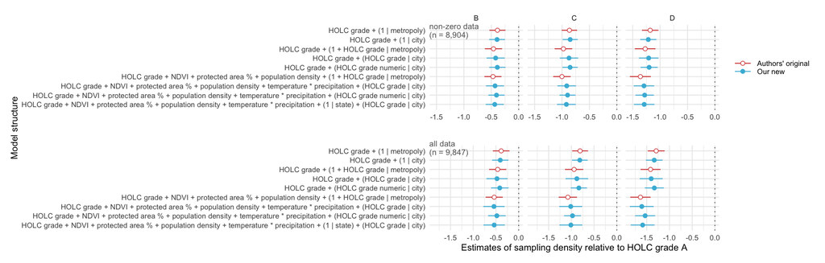

```r
    # combine
    (B1 / B2) + plot_layout(axis_titles = "collect"); #ggsave('Output/Fig_r2_sampling-density.jpg', width = 25, height = 8, units = 'cm')
```

**Figure r2 | Differences in estimated sampling density between HOLC grades.** Dots represent differences (in mean values) relative to HOLC grade A on ln-scale, horizontal lines indicate 95% confidence intervals, colour models specified by the authors (red empty circles) or by us (blue filled circles). The y-axis highlights specific model structure with variables in the paranthesis indicating random effects (left from `|` indicating random slopes and right from `|` indicating random intercepts). Top row contains estimates from the dataset with non-sampled polygons removed, bottom row the full dataset (where a small data-derived offset of 0.125 was added to the sampling density before ln-transformation).

## C. Completeness of sampling

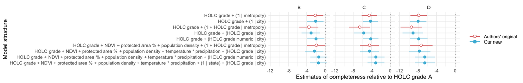

```r
hC = h[!is.na(completeness)]

# specified by the authors
c_ri <- lme4::lmer(completeness ~ holc_grade +
    (1 | msa_NAME),
    data = hC)

c_rirs    <- lme4::lmer(completeness ~ holc_grade +
    (1 + holc_grade | msa_NAME),
    data = hC)

c_fe_rirs <- lme4::lmer(completeness ~ holc_grade +
    scale(ndvi) + scale(pct_pa) + scale(pop_per_km) +
    (1 + holc_grade| msa_NAME),
    data = hC) # the authors' winnder

# specified by us
mC0 = lmer(completeness ~  holc_grade +
    (1 | city),
    data = hC
    )

mC1= lmer(completeness ~ holc_grade +
    (holc_grade | city),
    data = hC)

mC2= lmer(completeness ~ holc_grade +
    (holc_grade_num | city),
    data = hC)

mC1p= lmer(completeness ~ holc_grade +
    scale(ndvi) + scale(pct_pa) + scale(pop_per_km) +
    scale(mean_temp_c)*scale(mean_precip_mm) +
    (holc_grade | city),
    data = hC,
    control = lmerControl(optimizer = "bobyqa",
                         optCtrl = list(maxfun = 2e5))
    )

mC2p= lmer(completeness~ holc_grade +
    scale(ndvi) + scale(pct_pa) + scale(pop_per_km) +
    scale(mean_temp_c)*scale(mean_precip_mm) +
    (holc_grade_num | city),
    data = hC,
    control = lmerControl(optimizer = "bobyqa",
                         optCtrl = list(maxfun = 2e5))
    )

mC3p= lmer(completeness~ holc_grade +
    scale(ndvi) + scale(pct_pa) + scale(pop_per_km) +
    scale(mean_temp_c)*scale(mean_precip_mm) +
    (1 | state) + (holc_grade_num | city),
    data = hC,
    control = lmerControl(optimizer = "bobyqa",
                         optCtrl = list(maxfun = 2e5))
    )

# add models to a list
models_C <- list(
  c_ri      = c_ri,
  c_rirs    = c_rirs,
  c_fe_rirs = c_fe_rirs,
  mC0       = mC0,
  mC1       = mC1,
  mC2       = mC2,
  mC1p      = mC1p,
  mC2p      = mC2p,
  mC3p      = mC3p
)

# labels
model_labels_C <- c(
    c_ri      = "HOLC grade + (1 | metropoly)",
    c_rirs    = "HOLC grade + (1 + HOLC grade | metropoly)",
    c_fe_rirs = "HOLC grade + NDVI + protected area % + population density + (1 + HOLC grade | metropoly)",
    mC0       = "HOLC grade + (1 | city)",
    mC1       = "HOLC grade + (HOLC grade | city)",
    mC2       = "HOLC grade + (HOLC grade numeric | city)",
    mC1p      = "HOLC grade + NDVI + protected area % + population density + temperature * precipitation + (HOLC grade | city)",
    mC2p      = "HOLC grade + NDVI + protected area % + population density + temperature * precipitation + (HOLC grade numeric | city)",
    mC3p = "HOLC grade + NDVI + protected area % + population density + temperature * precipitation + (1 | state) + (HOLC grade | city)"
    )

# sort models
models_C_order <- c(
    "HOLC grade + (1 | metropoly)",
    "HOLC grade + (1 | city)",
    "HOLC grade + (1 + HOLC grade | metropoly)",
    "HOLC grade + (HOLC grade | city)",
    "HOLC grade + (HOLC grade numeric | city)",
    "HOLC grade + NDVI + protected area % + population density + (1 + HOLC grade | metropoly)",
    "HOLC grade + NDVI + protected area % + population density + temperature * precipitation + (HOLC grade | city)",
    "HOLC grade + NDVI + protected area % + population density + temperature * precipitation + (HOLC grade numeric | city)",
    "HOLC grade + NDVI + protected area % + population density + temperature * precipitation + (1 | state) + (HOLC grade | city)"
)

# extract
coef_df_C <- purrr::imap_dfr(models_C, ~ ext_fixef(.x) |> dplyr::mutate(model=.y))

coef_df_C <- coef_df_C %>%
mutate(model_label = factor(model_labels_C[model], levels = models_C_order)) %>% data.table()

# distinquish original models from our alternative ones
coef_df_C <- coef_df_C %>%
mutate(
    model_group = ifelse(grepl("^c_", model), "Authors' original", "Our new"),
    model_label = model_labels_C[model]
)

coef_df_C <- coef_df_C %>%
mutate(model_label = factor(model_label, levels = models_C_order))

red_ = "#D43F3AFF" # ggsci::pal_locuszoom()(5)
blue_ =  "#46B8DAFF"

# plot
ggplot(coef_df_C, aes(x = estimate, y = fct_rev(model_label))) +
geom_errorbar(aes(xmin = conf.low, xmax = conf.high,
    color = model_group),
    position = position_dodge(width = 0.6), height = 0) +
geom_point(aes(color = model_group, fill = model_group), position = position_dodge(width = 0.6), size = 1.5, shape =21) +
geom_vline(xintercept = 0, linetype = "dotted", color = "grey40") +
facet_wrap(~ holc_grade) +
scale_color_manual(values = c("#D43F3AFF","#46B8DAFF")) +
scale_fill_manual(values = c("white","#46B8DAFF")) +
#scale_shape_manual(values = c(21, 16), guide = "none") +  # shapes fixed, no shape legend
theme_minimal(base_size = 8) +
labs(
    x = "Estimates of completeness relative to HOLC grade A",
    y = "Model structure",
    color = NULL,
    fill = NULL
) +
theme(
    legend.key.height = unit(0.25, "cm")  # reduce vertical spacing between items
    #plot.subtitle = element_text(size = 7, colour = "grey40", margin = margin(b=-25))
    )#; ggsave('Output/Fig_r3_completeness.jpg', width = 25, height = 5, units = 'cm')
```

**Figure r3 | Differences in estimated sampling completeness between HOLC grades.** Dots represent differences (in mean values) relative to HOLC grade A, horizontal lines indicate 95% confidence intervals, colour models specified by the authors (red empty circles) or by us (blue filled circles). The y-axis highlights specific model structure with variables in the paranthesis indicating random effects (left from `|` indicating random slopes and right from `|` indicating random intercepts). n = 7187 polygons (neighbourhoods).

# 2. Replicating temporal trends

TODO: Peto, let’s decide whether the current i-iii order below is ok. I somehow feel that it might be better to first discuss Fig. 4; highlight the issue with the data and then use the correct data.

PETO: Why not, we can try it this way

The results on temporal trends contain three key outputs:  
i. Claim about 35.6% in relative disparity between HOLC grade A and D from 2000 to 2020.  
ii. Visualisation of temporal trends in Fig. 4.  
iii. General additive model on temporal trends in Table S4.

## i. Claim about 35.6% change in disparity

We did not find the code generating the 35.6% claim (Abstract p. 1869 & Results p. 1871), hence could only speculate how this was calculated. Using the authors data on sampling density per year and HOLC grade and calculating the ratio between A/D for 2020 and A/D for 2000 generated a different result (39.5%). This result seems to reflect the one (~40%) from Fig. 4 legend.

Moreover, plotting the disparity data shows a non-linear temporal relationship (Fig. XA) both after 2000 (left panel) and before 2000 right panel) and depending on the dataset may be even negative for A grade (Fig. XB). Such results question the use of arbitrary 2000 and 2020 comparison, unjustified by the authors, who also do not justify the exclusion of <2000 years. Including <2000 years shows even more complex picture, albeit the <2000 data might be less reliable because online platforms were non-existent (and likely also represent post-hoc data entries after GBIF platform was launched).

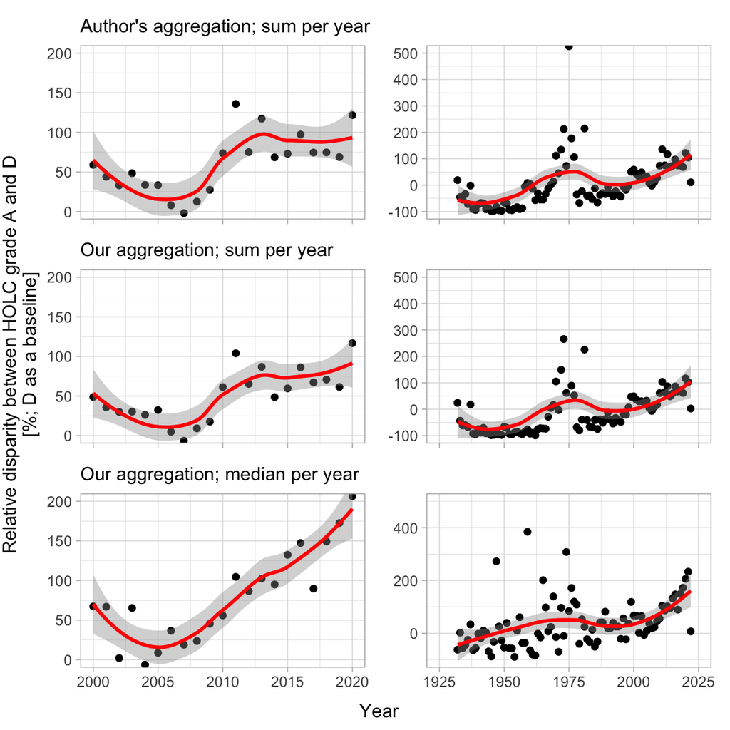

```r
# prepare authors' data
a = ttb[holc_grade%in%c('A','D')]
aw <- a[order(year),
            data.table::dcast(.SD, year ~ holc_grade, value.var = "sampling_density")]
aw[, dispar := 100*((A/D)-1)] #aw[, dispar := A/D]

# prepare our data
dd_ = dd[holc_grade%in%c('A','D')]
w <- dd_[order(year),
            data.table::dcast(.SD, year ~ holc_grade, value.var = "sampling_density")]
w[, dispar := 100*((A/D)-1)] #w[, dispar := A/D]

# prepare out data - median
dd_med = d_med[holc_grade%in%c('A','D')]
w_med <- dd_med[order(year),
            data.table::dcast(.SD, year ~ holc_grade, value.var = "sampling_density_med")]
w_med[, dispar := 100*((A/D)-1)] #w[, dispar := A/D]

# plot
g1a = ggplot(aw[year>1999 & year<2021], aes(x = year, y = dispar)) + geom_point() + stat_smooth(col = 'red') + labs(subtitle = "Author's aggregation; sum per year") + theme_light()
g1b = ggplot(aw, aes(x = year, y = dispar)) + geom_point() + stat_smooth(col = 'red')+ labs(subtitle = "") + theme_light()
  #(g1a|g1b) + plot_layout(axis_titles = "collect")

g2a = ggplot(w[year>1999 & year<2021], aes(x = year, y = dispar)) + geom_point() + stat_smooth(col = 'red')+ labs(subtitle = "Our aggregation; sum per year") + theme_light()
g2b = ggplot(w, aes(x = year, y = dispar)) + geom_point() + stat_smooth(col = 'red')+ labs(subtitle = "") + theme_light()
#(g2a|g2b) + plot_layout(axis_titles = "collect")

g3a = ggplot(w_med[year>1999 & year<2021], aes(x = year, y = dispar)) + geom_point() + stat_smooth(col = 'red')+ labs(subtitle = "Our aggregation; median per year") + theme_light()
g3b = ggplot(w_med, aes(x = year, y = dispar)) + geom_point() + stat_smooth(col = 'red')+ labs(subtitle = "") + theme_light()

#(g3a|g3b) + plot_layout(axis_titles = "collect")

g1a_ = g1a + theme(axis.title = element_blank(),  axis.text.x  = element_blank()) +
  coord_cartesian(ylim = c(0, 200)) + scale_y_continuous(breaks = seq(0,200, by = 50))
g1b_ = g1b + theme(axis.title = element_blank(),axis.text.x  = element_blank()) +
  coord_cartesian(xlim = c(1925, 2025), ylim = c(-100, 500)) + scale_y_continuous(breaks = seq(-100, 500, by = 100))

g2a_ = g2a + theme(axis.title = element_blank(), axis.text.x  = element_blank()) + coord_cartesian(ylim = c(0, 200)) + scale_y_continuous(breaks = seq(0,200, by = 50))
g2b_ = g2b + theme(axis.title = element_blank(),axis.text.x  = element_blank()) + coord_cartesian(xlim = c(1925, 2025), ylim = c(-100, 500))+ scale_y_continuous(breaks = seq(-100, 500, by = 100))

g3a_ = g3a + theme(axis.title = element_blank()) +coord_cartesian(ylim = c(0, 200)) + scale_y_continuous(breaks = seq(0,200, by = 50))
g3b_ = g3b + theme(axis.title = element_blank()) + coord_cartesian(xlim = c(1925, 2025), ylim = c(-100, 500))

p <- ((g1a_  / g2a_ / g3a_) | (g1b_ / g2b_ / g3b_)) +
  patchwork::plot_annotation(theme = ggplot2::theme(plot.subtitle = element_text(size = 11, colour = 'grey60'))) #& theme(plot.subtitle = element_text(size = 11, colour = 'grey60'))


# add one set of axis titles
ggdraw(xlim = c(-0.04, 1), ylim = c(-0.03, 1)) +
  draw_plot(p)+
  draw_label("Year", x = 0.5, y = -0.03, vjust = -1, size = 11) +
  draw_label("Relative disparity between HOLC grade A and D\n[%; D as a baseline]", x = -0.06, y = 0.5, angle = 90, vjust = 1.5, size = 11) #ggsave('Output/Fig_X-trends_3-rows_holc-area-b-all.jpg', units = 'cm', width = 15, height = 21)
```

**Figure X** | Change in relative disparity in sampling density between HOLC grade A and D over time. Each point represents percentage difference in sampling density of A given D (with D being a baseline) based on overall sampling density (i.e. sum of all A or D observation divided by the total area of A or D; the first two rows) or median sampling density per HOLC grade and year (bottom row). Lines represent local regression non-parametric smoothing and shaded areas its 95% confidence intervals. Top row represents the aggregation done by the authors, middle and bottom row the aggregation done by us. Note that the authors’ dataset did not contain area per year and category; hence, we were unable to compute the median sampling density for their dataset.

TODO: Martin check whether the above is meaningful and whether authors’ scripts cannot be tweeked to provide neighbourhoods ids.

## ii. Visualisation of temporal trends in Fig. 4.

The output that resembles Fig. 4 is located in two places, each yielding different results.

1. According to the authors’ README, the code `05_paper_1_analyses_R4_check.Rmd` should contain all key analyses for the paper. We did find a script with the heading “6 trends”, which generates trend lines for all four HOLC categories, but instead for sampling density ( depicted by authors’ Fig. 4), it depicts number of HOLC polygons that were sampled (A). To complete the picture, we also show the trends for number of sampling observations (B).

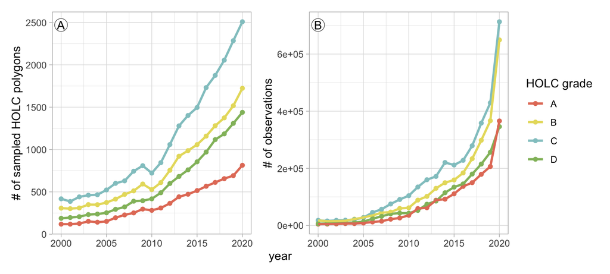

```r
# Here we show the authors original code with our adjustments indicate by MaPe

# a) prepare panel A and B

suppressWarnings({ #MaPe added, as well as package specs below
  counts_grade_year <-
    readr::read_csv('original_paper/Data/Biodiv_Greeness_Social/R1_biodiv_trend_by_time_holc_id_1933_2022.csv',#MaPe changed folder path from read_csv('original_paper/Data/Biodiv_Greeness_Social/R1_biodiv_trend_by_time_holc_id_1933_2022.csv')
    show_col_types = FALSE   # MaPe added to suppress readr column spec message
    ) |>
    dplyr::filter(holc_grade != 'E') |>
    dplyr::arrange(year, holc_grade) |>
    dplyr::group_by(year, holc_grade) |>
    dplyr::count() |>
    dplyr::summarise(cumsum = cumsum(n), .groups = "drop") # MaPe added ', .groups = "drop"' to suppress information messages
  })

tag_pos <- c(0.045, 0.94)   # x, y in panel [0..1]

# MaPe added color mapping
r_f4_A =
counts_grade_year |>
  dplyr::filter(year >= 2000 & year <= 2020) |>
  ggplot(aes(year, cumsum, col = forcats::fct_rev(holc_grade))) +  #MaPe changed group (group=holc_grade) to col to label the holc_grade lines
  geom_point() + #MaPe added to aid visualisation
  geom_line(linewidth = 1) +
  scale_color_manual(values = holc_pal, guide = guide_legend(reverse = TRUE), name = 'HOLC grade') + #MaPe added for consistent coloring
  circle_at_tag() +
  labs(y = '# of sampled HOLC polygons', tag='A') + #MaPe added
  theme_light() +  #MaPe added for consistency
  theme(legend.position = "right", plot.title = element_text(size = 10))+
  offset_tag #MaPe added


# MaPe added # of observations per year and HOLC
r_f4_B =
  ggplot(tt[year >= 2000 & year <= 2020], aes(year, n_obs, col = forcats::fct_rev(holc_grade))) +  #MaPe changed group (group=holc_grade) to col to label the holc_grade lines
  geom_point() + #MaPe added to aid visualisation
  geom_line(size = 1) +
  scale_color_manual(values = holc_pal, guide = guide_legend(reverse = TRUE), name = 'HOLC grade') + #MaPe added for consistent coloring
  circle_at_tag() +
  labs(y = '# of observations', tag='B') + #MaPe added
  theme_light() +#MaPe added for consistency
  theme(legend.position = "right", plot.title = element_text(size = 10))+
  offset_tag #MaPe added


(r_f4_A + r_f4_B) +
plot_layout(guides = "collect", axis_titles = 'collect') #; ggsave('Output/Fig_r4_count_v2.jpg', width= 20, height = 9, units ='cm')
```

**Figure X2** | Change in # of sampled polygons (A) and # of observations (B) according to HOLC grade over time. Each point represents the sum per year. Lines aid the visualisation by connecting the points. Colour indicates HOLC grade category.

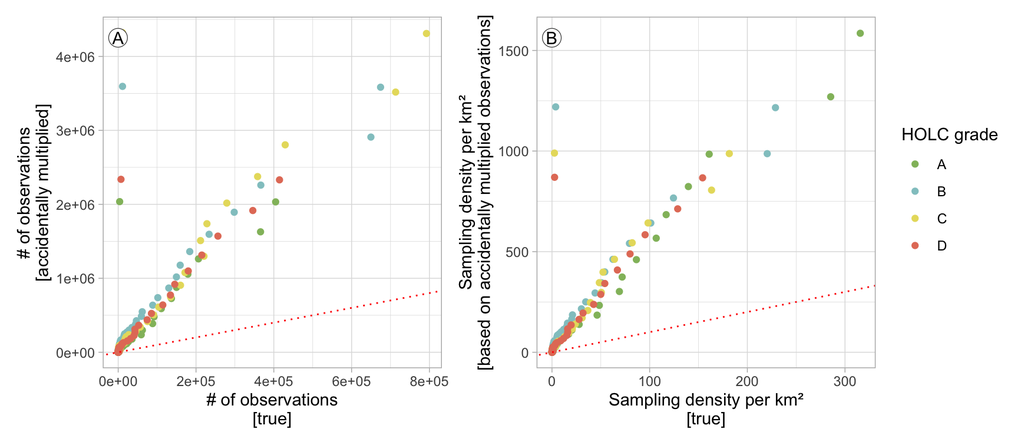

```r
holc_area = copy(holc_area_sum_b)
setnames(holc_area, 'sum_area_holc_km2', 'area_sum')
# prepare the multiplied dataset (chunk of code from `04_R4_uneven_biodiversity_data_2023.R` (L410-20))
require(plyr) # the package causeing the multiplications
temporal_trend = read.table("original_paper/Data/Biodiv_Greeness_Social/R1_biodiv_trend_by_time_holc_id_1933_2022.csv",
                            header = TRUE,sep = ",")
# names(temporal_trend) <- c('Year','holc_grade','Type','holc_polygon_id', 'Sum')
names(temporal_trend) <- c('Year','holc_grade', 'Sum')
temporal_trend = temporal_trend %>% filter(holc_grade != 'E')

temporal_all_data = ddply(temporal_trend, 'holc_grade', function(x){
  ddply(x, 'Year', function(z){

    data.frame(
      Year = unique(z$Year),
      holc_grade = unique(z$holc_grade),
      n_obs = sum(z$Sum,na.rm=T)
      #    n_obs_cum = cumsum(z$Sum)
    )

  })
})

tmpppp = temporal_all_data %>% group_by(holc_grade, Year) # %>% mutate(cumsum = cumsum(n_obs))

trend_A = tmpppp %>% filter(holc_grade == 'A') %>% mutate(cumsum_n_obs = cumsum(n_obs)) %>% left_join(holc_area) %>% mutate(sampling_density = cumsum_n_obs /area_sum )

trend_B  = tmpppp %>% filter(holc_grade == 'B') %>% mutate(cumsum_n_obs = cumsum(n_obs)) %>% left_join(holc_area) %>% mutate(sampling_density = cumsum_n_obs /area_sum )

trend_C  = tmpppp %>% filter(holc_grade == 'C') %>% mutate(cumsum_n_obs = cumsum(n_obs)) %>% left_join(holc_area) %>% mutate(sampling_density = cumsum_n_obs /area_sum )

trend_D  = tmpppp %>% filter(holc_grade == 'D') %>% mutate(cumsum_n_obs = cumsum(n_obs)) %>% left_join(holc_area) %>% mutate(sampling_density = cumsum_n_obs /area_sum )

mul = data.table(rbind(trend_A,trend_B,trend_C,trend_D))

# load the correct dataset (note that for consistency we use the same code as above, but without the plyr package. Note, the code can be drastically simplified by removing the redundant parts and using data.table as we do in the above section [Code to load tools and data](Code to load tools and data).

detach("package:plyr", unload = TRUE, character.only = TRUE) #unload plyr package to recieve a correct picture

# authors' code (L412-20); note that the following code that multiplied the datase is unnecessary as tmppp already contains number of observations and hence only area needed to be joined
trend_A = tmpppp %>% filter(holc_grade == 'A') %>% mutate(cumsum_n_obs = cumsum(n_obs)) %>% left_join(holc_area) %>% mutate(sampling_density = cumsum_n_obs /area_sum )

trend_B  = tmpppp %>% filter(holc_grade == 'B') %>% mutate(cumsum_n_obs = cumsum(n_obs)) %>% left_join(holc_area) %>% mutate(sampling_density = cumsum_n_obs /area_sum )

trend_C  = tmpppp %>% filter(holc_grade == 'C') %>% mutate(cumsum_n_obs = cumsum(n_obs)) %>% left_join(holc_area) %>% mutate(sampling_density = cumsum_n_obs /area_sum )

trend_D  = tmpppp %>% filter(holc_grade == 'D') %>% mutate(cumsum_n_obs = cumsum(n_obs)) %>% left_join(holc_area) %>% mutate(sampling_density = cumsum_n_obs /area_sum )

ok = data.table(rbind(trend_A,trend_B,trend_C,trend_D))

ok[, cumsum_n_obs_mul:=mul$cumsum_n_obs]
ok[, sampling_density_ok := cumsum_n_obs/area_sum]
ok[, sampling_density_mul := cumsum_n_obs_mul/area_sum]

# prepare for plotting
cor_a =
ggplot(ok, aes(x = cumsum_n_obs, y = cumsum_n_obs_mul, col = holc_grade)) +
  geom_point() +
  geom_abline(slope = 1, intercept = 0, linetype = "dotted", col = 'red') +
  labs(x = "# of observations\n[true]", y = "# of observations\n[accidentally multiplied]")+
  scale_color_manual(values = holc_pal, name = 'HOLC grade') +
  theme_light() +
  circle_at_tag() + labs(tag = "A") + offset_tag

cor_b =
ggplot(ok, aes(x = sampling_density_ok, y = sampling_density_mul, col = holc_grade))  +
  geom_point() +
  geom_abline(slope = 1, intercept = 0, linetype = "dotted", col = 'red') +
  labs(x = "Sampling density per km²\n[true]", y = "Sampling density per km²\n[based on accidentally multiplied observations]") +
  scale_color_manual(values = holc_pal, name = 'HOLC grade') +
  theme_light() +
  circle_at_tag() + labs(tag = "B") + offset_tag

(cor_a | cor_b) + plot_layout(guides = "collect")#ggsave('Output/Fig_check_wrong_data.jpg', width= 23, height = 10, units ='cm')
```

**Figure O** | Relationship between the correct dataset and authors’ accidentally multiplied one. Each point represents # of observations (A) and sampling density in km² (B) per HOLC grade and year, point colour indicates HOLC grade. Dotted line indicates unity - same value for true and authors’ data.

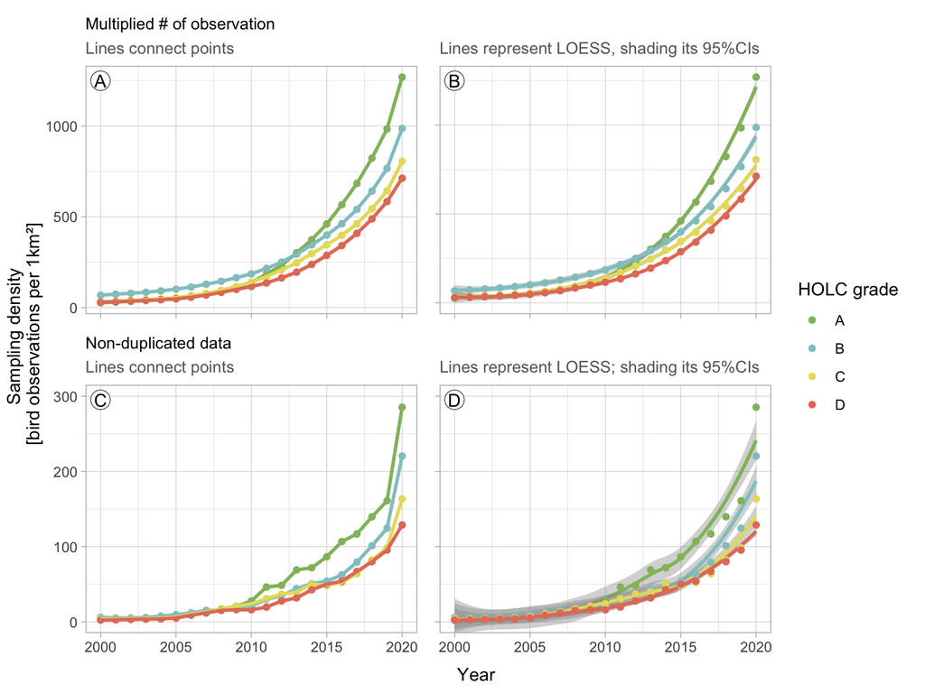

```r
# b)
# prepare panels A and B with the original figure
r_f4_A =
ggplot(mul[Year >= 2000 & Year <= 2020], aes(x = Year, y = sampling_density), fill = holc_grade) +
geom_point(aes(color = holc_grade)) + # MaPe added to aid visualisation
geom_line(aes(color = holc_grade), size = 1, show.legend = FALSE) +
#stat_smooth(aes(color = holc_grade), size = 1) +
#coord_cartesian(ylim = c(0, 300)) + scale_y_continuous(breaks = seq(0, 300, by = 100)) + # MaPe added
scale_color_manual(values = holc_pal, name = 'HOLC grade') +
labs(title = "Multiplied # of observation", subtitle = 'Lines connect points', tag='A', y = 'Sampling density\n[bird observations per km²]') + # MaPe added subtitle
theme_light()+
#theme(legend.position = 'none') + # MaPe hashtagged out to aid visualisation
theme( plot.subtitle = element_text(size = 10, colour = "grey40"), plot.title = element_text(size = 10))

r_f4_B =
ggplot(mul[Year >= 2000 & Year <= 2020], aes(x = Year, y = sampling_density), fill = holc_grade) +
stat_smooth(aes(color = holc_grade), size = 1, show.legend = FALSE) +
geom_point(aes(color = holc_grade)) +
#stat_smooth(aes(color = holc_grade), size = 1) +
#coord_cartesian(ylim = c(0, 300)) + scale_y_continuous(breaks = seq(0, 300, by = 100)) + # MaPe added
scale_color_manual(values = holc_pal, name = 'HOLC grade') +
labs(title = "", subtitle = 'Lines represent LOESS, shading its 95%CIs', tag='B', y = 'Sampling density\n [bird observations per 1km²]') + # MaPe added subtitle
theme_light()+
#theme(legend.position = 'none') + # MaPe hashtagged out to aid visualisation
theme(legend.position = 'none', plot.subtitle = element_text(size = 10, colour = "grey40"), plot.title = element_text(size = 10))


# prepare panels D and C with the corrected data

# copy of the L390-430 of 04_R4_uneven_biodiversity_data_2023.R, with changed folder path
# Load 1933-2022 data
temporal_trend = read.table('original_paper/Data/Biodiv_Greeness_Social/R1_biodiv_trend_by_time_holc_id_1933_2022.csv', header= T,sep=',')
# names(temporal_trend) <- c('Year','holc_grade','Type','holc_polygon_id', 'Sum')
names(temporal_trend) <- c('Year','holc_grade', 'Sum')
temporal_trend = temporal_trend %>% filter(holc_grade != 'E')
# MaPe hashtagged out as it needed other data, not relevant for the current case: sum(temporal_2000_2020$Sum,na.rm=T) / sum(temporal_trend$Sum,na.rm=T) # 77.8 % of biodiversity data collected in last 20 years !

temporal_all_data = plyr::ddply(temporal_trend, 'holc_grade', function(x){
  plyr::ddply(x, 'Year', function(z){
    data.frame(
      Year = unique(z$Year),
      holc_grade = unique(z$holc_grade),
      n_obs = sum(z$Sum,na.rm=T)
      #    n_obs_cum = cumsum(z$Sum)
    )

  })
})

tmpppp = temporal_all_data %>% group_by(holc_grade, Year) # %>% mutate(cumsum = cumsum(n_obs))

trend_A = tmpppp %>% filter(holc_grade == 'A') %>% mutate(cumsum_n_obs = cumsum(n_obs)) %>% left_join(holc_area) %>% mutate(sampling_density = cumsum_n_obs /area_sum )

trend_B  = tmpppp %>% filter(holc_grade == 'B') %>% mutate(cumsum_n_obs = cumsum(n_obs)) %>% left_join(holc_area) %>% mutate(sampling_density = cumsum_n_obs /area_sum )

trend_C  = tmpppp %>% filter(holc_grade == 'C') %>% mutate(cumsum_n_obs = cumsum(n_obs)) %>% left_join(holc_area) %>% mutate(sampling_density = cumsum_n_obs /area_sum )

trend_D  = tmpppp %>% filter(holc_grade == 'D') %>% mutate(cumsum_n_obs = cumsum(n_obs)) %>% left_join(holc_area) %>% mutate(sampling_density = cumsum_n_obs /area_sum )

temporal_all_data = rbind(trend_A,trend_B,trend_C,trend_D)

# Plot temporal trend: 2000-2020; same as in the script, but showing legend
r_f4_C =
temporal_all_data %>%
filter(Year >= 2000 & Year <= 2020) %>%
#filter(Year >= 2010 & Year <= 2019) %>%
#filter(Year <= 2020) %>%
ggplot(aes(x = Year, y = sampling_density), fill = holc_grade) +
geom_point(aes(color = holc_grade)) + # MaPe added to aid visualisation
geom_line(aes(color = holc_grade), size = 1, show.legend = FALSE) +
#stat_smooth(aes(color = holc_grade), size = 1) +
coord_cartesian(ylim = c(0, 300)) + scale_y_continuous(breaks = seq(0, 300, by = 100)) + # MaPe added
scale_color_manual(values = holc_pal, name = 'HOLC grade') +
labs(title = "Non-duplicated data", subtitle = 'Lines connect points', tag='C', y = 'Sampling density\n [bird observations per km²]') + # MaPe added subtitle
theme_light()+
#theme(legend.position = 'none') + # MaPe hashtagged out to aid visualisation
theme( plot.subtitle = element_text(size = 10, colour = "grey40"), plot.title = element_text(size = 10))

# ggsave('Output/Fig_r4_density.jpg', width= 15, height = 15, units ='cm')

# MaPe - LOESS smoothed
r_f4_D =
temporal_all_data %>%
filter(Year >= 2000 & Year <= 2020) %>%
#filter(Year >= 2010 & Year <= 2019) %>%
#filter(Year <= 2020) %>%
ggplot(aes(x = Year, y = sampling_density), fill = holc_grade) +
stat_smooth(aes(color = holc_grade), size = 1, show.legend = FALSE) +
geom_point(aes(color = holc_grade)) + # MaPe added to aid visualisation
#geom_line(aes(color = holc_grade), size = 1) +
coord_cartesian(ylim = c(0, 300)) + scale_y_continuous(breaks = seq(0, 300, by = 100)) + # MaPe added
scale_color_manual(values = holc_pal, name = 'HOLC grade') +
labs(subtitle = 'Lines represent LOESS; shading its 95%CIs', tag='D', y = 'Sampling density\n [bird observations per km²]') + # MaPe added subtitle
theme_light()+
#theme(legend.position = 'none') + # MaPe hashtagged out to aid visualisation
theme( legend.position = 'none', plot.subtitle = element_text(size = 10, colour = "grey40"), plot.title = element_text(size = 10))
#g2; ggsave('Output/Fig_r4_density_LOESS.jpg', width= 15, height = 15, units ='cm')

# COMBINE ALL
#(r_f4_C + r_f4_D) +
#plot_layout(guides = "collect", axis_titles = 'collect')
#ggsave('Output/Fig_r4_AB.jpg', width= 20, height = 11, units ='cm')

#((r_f4_A + r_f4_B) / (r_f4_C + r_f4_D)) + plot_layout(guides = "collect", axis_titles = 'collect')

r_f4_A_ = r_f4_A +  theme(axis.title = element_blank(),  axis.text.x  = element_blank()) + circle_at_tag() + labs(tag = "A") + offset_tag
r_f4_B_ = r_f4_B + theme(axis.title = element_blank(),axis.text  = element_blank()) + circle_at_tag() + labs(tag = "B") + offset_tag
r_f4_C_ = r_f4_C + theme(axis.title = element_blank()) + circle_at_tag() + labs(tag = "C") + offset_tag
r_f4_D_ = r_f4_D + theme(axis.title = element_blank(), axis.text.y  = element_blank()) + circle_at_tag() + labs(tag = "D") + offset_tag

pp = ((r_f4_A_ + r_f4_B_) / (r_f4_C_ + r_f4_D_))+ plot_layout(guides = "collect") #+ plot_layout(guides = "collect", axis_titles = 'collect')

ggdraw(xlim = c(-0.03, 1), ylim = c(-0.03, 1)) +
  draw_plot(pp)+
  draw_label("Year", x = 0.5, y = -0.03, vjust = -1, size = 11) +
  draw_label('Sampling density\n [bird observations per 1km²]', x = -0.04, y = 0.5, angle = 90, vjust = 1.5, size = 11)#; ggsave('Output/Fig_rFig4_abcd_circle.jpg', width= 20, height = 15, units ='cm')
```

**Figure X3** | Change in sampling density between HOLC grades over time. Each point represents sampling density per HOLC grade and year (sum of all observations divided by the total area for the given grade). Lines in the left pannels connect the points, in the right panels represent local regression non-parametric smoothing and shaded areas its 95% confidence intervals. Top row represents the accidently multiplied observations used by the author’s, bottom row the correct number of observation.

The corrected figure, we have generated, shows that (i) sampling for all categories was similar until ±2009, then (ii) the differences in sampling between categories likely increased, but then (iii) leveled off. Note however, that such differences are easier to see if we plot the relative difference (Fig. X) or the sampling densities of two categories against each other (Fig. X4).

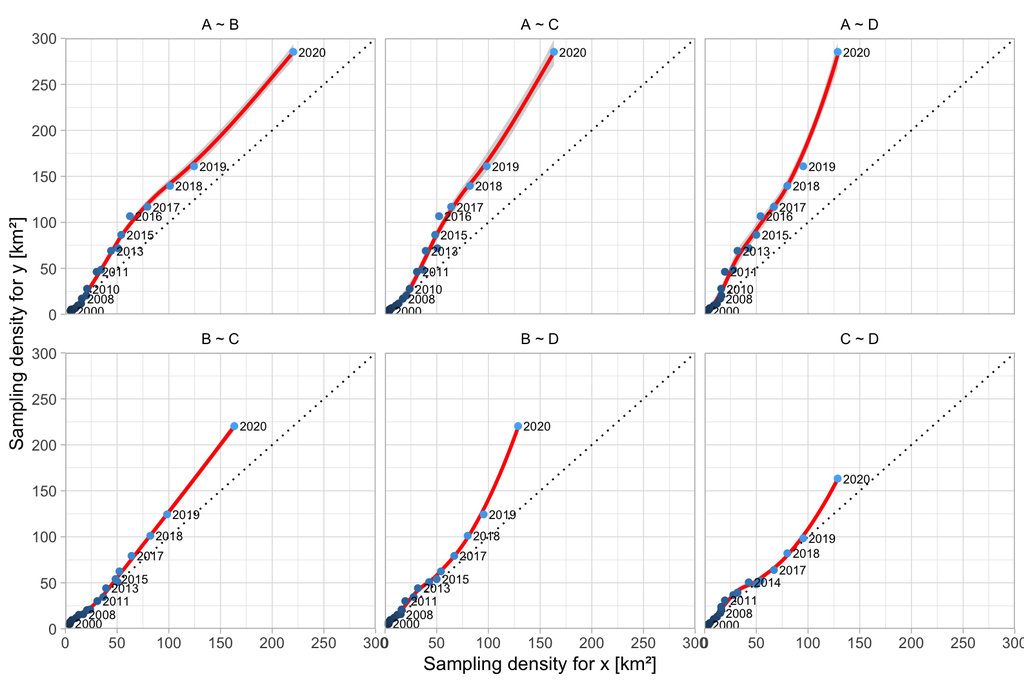

```r
# all pairwise combinations you want
pairs <- data.table(
  x = c("D","D","D","C","C","B"),
  y = c("A","B","C","A","B","A")
)

# join to create plotting dataset
plotdat <- pairs[, .(x, y)][
  , merge(ttb[holc_grade==x], ttb[holc_grade==y], by="year", suffixes=c(".x",".y")),
  by=.(x,y)
][, pair := paste0(y, " ~ ", x)]

# plot
ggplot(plotdat[year >= 2000 & year <= 2020], aes(sampling_density.x, sampling_density.y)) +
  geom_abline(slope=1, intercept=0, linetype="dotted", color="black") +
  geom_smooth(col = 'red') +
  geom_point(aes(col=year), show.legend = FALSE) +
  geom_text(aes(label=year), hjust=-0.2, size=2.5, check_overlap=TRUE) +
  scale_x_continuous(breaks=seq(0,300,50), expand = c(0,0)) +
  scale_y_continuous(breaks=seq(0,300,50), expand = c(0,0)) +
  coord_cartesian(xlim=c(0,300), ylim=c(0,300)) +
  facet_wrap(~pair, scales="fixed") +
  labs(x="Sampling density for x [km²]", y="Sampling density for y [km²]")+
  theme_light()+
  theme(
    strip.background = element_blank(),       # remove grey panel background
    strip.text = element_text(color = "black") # make labels black
  ) #; ggsave('Output/Fig_r4_alternative_new.jpg', width= 21, height = 14, units ='cm')
```

**Figure X4** | Change in sampling density between HOLC grades over time. Each point represents sampling density per HOLC grade and year (sum of all observations per divided by the total a for the given grade) with the year indicated for some of those. Red lines with shaded area represent local regression non-parametric smoothing with its 95% confidence intervals. Dotted line indicates unity, i.e. point on the line highlight same sampling density, above the line higher sampling for y and below the line higher sampling for x.

This figures highlights the effects discussed by the authors. However, same as the intended Fig. 4, the data behind these plots are heavily psedoreplicated because they do not account for spatial and temporal non-independence of data points. The figures shows that 2020 is an off year and that likely there was an increase around 2009 and that disparity remained (did not increase much after).

## iii. General additive model on temporal trends in Table S4

### Computational reproducibility

We were initially unable to generate the results found in Table S4. The authors’ script provided different outputs, both using multiplied and corrected dataset. However, the scripts contained models where sampling density was not ln-transformed, whereas the description of the authors’ Table S4 indicated log-transformation. Using ln-transformed sampling density and multiplied dataset did produce the outcome that is in authors’ Table S4 (see below Table S1).

**Table S1a | Change in sampling density across time in relations to HOLC grade**

```r
m_density_mul = glm((sampling_density) ~ Year * holc_grade, data = mul[Year %in% c(2000:2020)])
m_density_ok = glm((sampling_density) ~ Year * holc_grade, data = ok[Year %in% c(2000:2020)])

tab_model(m_density_mul, m_density_ok,  auto.label = T, string.ci='95%CI', title = "Generalized linear model", dv.labels = c("Multiplied # of observations", "Actual # of observations")) # m = lm(log(sampling_density) ~ Year * holc_grade, data = ok[Year %in% c(2000:2020)]); summary(glht(m)) # gives even less clear relationship
```

Generalized linear model

|  | Multiplied # of observations |  |  | Actual # of observations |  |  |
| --- | --- | --- | --- | --- | --- | --- |
| Predictors | Estimates | 95%CI | p | Estimates | 95%CI | p |
| (Intercept) | -102300.35 | -119706.97 – -84893.73 | **<0.001** | -19815.42 | -23700.19 – -15930.64 | **<0.001** |
| Year | 51.05 | 42.39 – 59.71 | **<0.001** | 9.89 | 7.96 – 11.82 | **<0.001** |
| holc grade [B] | 28142.26 | 3525.58 – 52758.94 | **0.025** | 5914.53 | 420.63 – 11408.43 | **0.035** |
| holc grade [C] | 36101.69 | 11485.00 – 60718.37 | **0.004** | 8703.71 | 3209.81 – 14197.61 | **0.002** |
| holc grade [D] | 44304.18 | 19687.50 – 68920.87 | **<0.001** | 9652.28 | 4158.38 – 15146.18 | **0.001** |
| Year × holc grade [B] | -14.01 | -26.26 – -1.76 | **0.025** | -2.95 | -5.68 – -0.22 | **0.034** |
| Year × holc grade [C] | -18.00 | -30.25 – -5.75 | **0.004** | -4.34 | -7.07 – -1.61 | **0.002** |
| Year × holc grade [D] | -22.10 | -34.35 – -9.85 | **<0.001** | -4.82 | -7.55 – -2.08 | **0.001** |
| Observations | 84 |  |  | 84 |  |  |
| R<sup>2</sup> | 0.805 |  |  | 0.743 |  |  |

**Table S1b | Change in sampling density across time in relations to HOLC grade**

```r
m_density_mul_ln = glm(log(sampling_density) ~ Year * holc_grade, data = mul[Year %in% c(2000:2020)])
m_density_ok_ln = glm(log(sampling_density) ~ Year * holc_grade, data = ok[Year %in% c(2000:2020)])

tab_model(m_density_mul_ln, m_density_ok_ln,  auto.label = T, string.ci='95%CI', title = "Generalized linear model on ln(sampling density)", dv.labels = c("Multiplied # of observations", "Actual # of observations"))
```

Generalized linear model on ln(sampling density)

|  | Multiplied # of observations |  |  | Actual # of observations |  |  |
| --- | --- | --- | --- | --- | --- | --- |
| Predictors | Estimates | 95%CI | p | Estimates | 95%CI | p |
| (Intercept) | -400.14 | -414.05 – -386.24 | **<0.001** | -451.54 | -475.31 – -427.76 | **<0.001** |
| Year | 0.20 | 0.19 – 0.21 | **<0.001** | 0.23 | 0.21 – 0.24 | **<0.001** |
| holc grade [B] | 138.28 | 118.62 – 157.95 | **<0.001** | 90.81 | 57.19 – 124.44 | **<0.001** |
| holc grade [C] | 67.25 | 47.59 – 86.91 | **<0.001** | 74.69 | 41.06 – 108.31 | **<0.001** |
| holc grade [D] | 73.41 | 53.74 – 93.07 | **<0.001** | 44.97 | 11.35 – 78.60 | **0.009** |
| Year × holc grade [B] | -0.07 | -0.08 – -0.06 | **<0.001** | -0.05 | -0.06 – -0.03 | **<0.001** |
| Year × holc grade [C] | -0.03 | -0.04 – -0.02 | **<0.001** | -0.04 | -0.05 – -0.02 | **<0.001** |
| Year × holc grade [D] | -0.04 | -0.05 – -0.03 | **<0.001** | -0.02 | -0.04 – -0.01 | **0.008** |
| Observations | 84 |  |  | 84 |  |  |
| R<sup>2</sup> | -0.921 |  |  | -0.573 |  |  |

**Table S1c | Change in sampling density across time in relations to HOLC grade**

```r
gam_density_mul = gam(sampling_density ~ Year * holc_grade, data = mul[Year %in% c(2000:2020)])

gam_density_ok = gam(sampling_density ~ Year * holc_grade, data = ok[Year %in% c(2000:2020)])

tab_model(gam_density_mul, gam_density_ok, auto.label = T, string.ci='95%CI', title = "Generalized additive model", dv.labels = c("Multiplied # of observations", "Actual # of observations"))
```

Generalized additive model

|  | Multiplied # of observations |  |  | Actual # of observations |  |  |
| --- | --- | --- | --- | --- | --- | --- |
| Predictors | Estimates | 95%CI | p | Estimates | 95%CI | p |
| (Intercept) | -102300.35 | -119988.58 – -84612.12 | **<0.001** | -19815.42 | -23763.04 – -15867.79 | **<0.001** |
| Year | 51.05 | 42.25 – 59.85 | **<0.001** | 9.89 | 7.92 – 11.85 | **<0.001** |
| holc grade [B] | 28142.26 | 3127.33 – 53157.19 | **0.028** | 5914.53 | 331.75 – 11497.32 | **0.038** |
| holc grade [C] | 36101.69 | 11086.75 – 61116.62 | **0.005** | 8703.71 | 3120.92 – 14286.49 | **0.003** |
| holc grade [D] | 44304.18 | 19289.25 – 69319.12 | **0.001** | 9652.28 | 4069.50 – 15235.06 | **0.001** |
| Year × holc grade [B] | -14.01 | -26.46 – -1.57 | **0.028** | -2.95 | -5.73 – -0.17 | **0.038** |
| Year × holc grade [C] | -18.00 | -30.45 – -5.56 | **0.005** | -4.34 | -7.12 – -1.56 | **0.003** |
| Year × holc grade [D] | -22.10 | -34.54 – -9.65 | **0.001** | -4.82 | -7.59 – -2.04 | **0.001** |
| Observations | 84 |  |  | 84 |  |  |
| R<sup>2</sup> | 0.787 |  |  | 0.719 |  |  |

**Table S1d | Change in sampling density across time in relations to HOLC grade**

```r
gam_density_mul_ln = gam(log(sampling_density) ~ Year * holc_grade, data = mul[Year %in% c(2000:2020)])

gam_density_ok_ln = gam(log(sampling_density) ~ Year * holc_grade, data = ok[Year %in% c(2000:2020)])

tab_model(gam_density_mul_ln, gam_density_ok_ln, auto.label = T, string.ci='95%CI', title = "Generalized additive model on ln(sampling density)", dv.labels = c("Multiplied # of observations", "Actual # of observations")) #summary(glht(gam_density_ok_ln)) corrected p-values
```

Generalized additive model on ln(sampling density)

|  | Multiplied # of observations |  |  | Actual # of observations |  |  |
| --- | --- | --- | --- | --- | --- | --- |
| Predictors | Estimates | 95%CI | p | Estimates | 95%CI | p |
| (Intercept) | -400.14 | -414.27 – -386.01 | **<0.001** | -451.54 | -475.70 – -427.38 | **<0.001** |
| Year | 0.20 | 0.19 – 0.21 | **<0.001** | 0.23 | 0.21 – 0.24 | **<0.001** |
| holc grade [B] | 138.28 | 118.30 – 158.26 | **<0.001** | 90.81 | 56.64 – 124.98 | **<0.001** |
| holc grade [C] | 67.25 | 47.27 – 87.23 | **<0.001** | 74.69 | 40.52 – 108.86 | **<0.001** |
| holc grade [D] | 73.41 | 53.43 – 93.39 | **<0.001** | 44.97 | 10.80 – 79.14 | **0.011** |
| Year × holc grade [B] | -0.07 | -0.08 – -0.06 | **<0.001** | -0.05 | -0.06 – -0.03 | **<0.001** |
| Year × holc grade [C] | -0.03 | -0.04 – -0.02 | **<0.001** | -0.04 | -0.05 – -0.02 | **<0.001** |
| Year × holc grade [D] | -0.04 | -0.05 – -0.03 | **<0.001** | -0.02 | -0.04 – -0.01 | **0.010** |
| Observations | 84 |  |  | 84 |  |  |
| R<sup>2</sup> | 0.991 |  |  | 0.982 |  |  |

Note, it is unclear why generalised additive model was used as no wave form was fitted (i.e. simple Gaussian model was used).

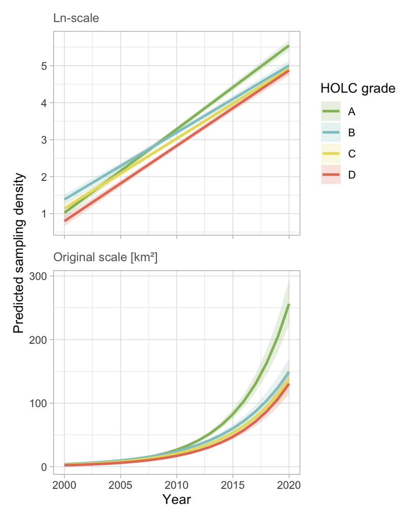

```r
# plot predictions
# newdata grid
newD <- CJ(Year = 2000:2020, holc_grade = unique(ok$holc_grade))

# predictions + 95%CI on log scale
pr <- predict(gam_density_ok_ln, newdata = newD, se.fit = TRUE)
newD[, `:=`(fit = pr$fit, se = pr$se.fit)]
newD[, `:=`(lwr = fit - 1.96 * se, upr = fit + 1.96 * se)]

# plot on log scale
fy1 =
ggplot(newD, aes(x = Year, y = fit, colour = holc_grade, fill = holc_grade)) +
  geom_ribbon(aes(ymin = lwr, ymax = upr), alpha = 0.2, colour = NA) +
  geom_line(size = 1) +
  scale_color_manual(values = holc_pal, name = 'HOLC grade') +
  scale_fill_manual(values = holc_pal, name = 'HOLC grade') +
  labs(y = "Predicted sampling density", x = 'Year', subtitle = 'Ln-scale') +
  theme_light() +
  theme(plot.subtitle = element_text(size = 10, colour = "grey40"),
        axis.title.x = element_blank(),
        axis.text.x  = element_blank()
        )

# plot: back-transform to original scale (median on original scale)
newD_bt <- copy(newD)[, `:=`(fit_bt = exp(fit), lwr_bt = exp(lwr), upr_bt = exp(upr))]

fy2 =
ggplot(newD_bt, aes(x = Year, y = fit_bt, colour = holc_grade, fill = holc_grade)) +
  geom_ribbon(aes(ymin = lwr_bt, ymax = upr_bt), alpha = 0.2, colour = NA) +
  geom_line(size = 1) +
  scale_color_manual(values = holc_pal, name = 'HOLC grade') +
  scale_fill_manual(values = holc_pal, name = 'HOLC grade') +
  labs(y = "Predicted sampling density", x = 'Year', subtitle = 'Original scale [km²]') +
  theme_light() +
  theme(legend.position = 'none',
        plot.subtitle = element_text(size = 10, colour = "grey40")
        )

 (fy1 / fy2)+ plot_layout(axis_title = "collect") #; ggsave('Output/Fig_Y.jpg', width= 12, height = 15, units ='cm')
```

**Figure Y** | Predicted sampling density between HOLC grades over time. Lines with shaded areas represent generalized additive model predictions of sampling density on ln-scale (top) and km² bottom. N = 84 observations (sum of all observations per year and grade divided by the total area for the given grade). Note, however, that it is unclear why generalised additive model was used as no wave form was fitted (i.e. simple Gaussian model was used).

### Robustness reproducibility

To account for non-independence of unique polygons and their data across years, we have created a dataset with the number of observations for each unique polygon and year (i.e. city-specific HOLC-grades and sampling polygon ids). Note that some polygons have missing polygon ids and hence merging with polygon area was not possible (n = 77,538 polygon-year recors).

We then specified mixed-effect models with sampling density (km²) as a response and year (continuous) in interaction with HOLC grade (four-level factor) as predictors while controlling for non-independence of data points in the random effects. We specified 6 models varying in the random effects and compared their estimates for the fixed effect predictors:

1. Random intercept of state, city within state and unique sampling polygon id.
2. Same as (1) but explicitly nested.
3. Same as (1), but with random slope of year within city.
4. Same as (1), but with random slope of year within polygon.
5. Same as (2), but with random slope of year.
6. Random slope of year within HOLC grade, nested within city and state (random intercepts) and separate random intercept for unique polygon id.

#### A. Contrasts

```r
  # check distributions
  #ggplot(d, aes(sum_bird_obs))+geom_density() + scale_x_continuous(trans ='log')
  #ggplot(d, aes(sampling_density))+geom_density() + scale_x_continuous(trans ='log')
  #ggplot(d00, aes(sampling_density))+geom_density() + scale_x_continuous(trans ='log')

  # MODELS 2000-2020
  # 0) model per holc grade
  sum_m  <- lm(scale(log(sampling_density)) ~ holc_grade_D*scale(year), tt00)

  # 1) model set per polygon
  maD = lmer(scale(log(sampling_density)) ~ holc_grade_D*scale(year) +
              (1|state) + (1|city_state) + (1|id2),
              d00,
              control = lmerControl(
                  optimizer = "bobyqa",
                  optCtrl = list(maxfun = 2e5)
              )
            )

  mbD = lmer(scale(log(sampling_density)) ~ holc_grade_D*scale(year) +
              (1|state/city_state/holc_grade/id2),
              d00,
              control = lmerControl(
                  optimizer = "bobyqa",
                  optCtrl = list(maxfun = 2e5)
              )
            )

  mas1D = lmer(scale(log(sampling_density)) ~ holc_grade_D*scale(year) +
              (1|state) + (scale(year)|city_state) + (1|id2),
              d00,
              control = lmerControl(
                  optimizer = "bobyqa",
                  optCtrl = list(maxfun = 2e5)
              )
              )
  mas2D = lmer(scale(log(sampling_density)) ~ holc_grade_D*scale(year) +
              (1|state) + (scale(year)|city_state) + (1|id2),
              d00,
              control = lmerControl(
                  optimizer = "bobyqa",
                  optCtrl = list(maxfun = 2e5)
              )
              )
  mbs1D = lmer(scale(log(sampling_density)) ~ holc_grade_D*scale(year) +
              (scale(year)|state/city_state/holc_grade/id2),
              d00,
              control = lmerControl(
                  optimizer = "bobyqa",
                  optCtrl = list(maxfun = 2e5)
              )
              )

  msab1D = lmer(scale(log(sampling_density)) ~ holc_grade_D*scale(year) +
              (scale(year)|state/city_state/holc_grade) + (1|id2),
              d00,
              control = lmerControl(
                  optimizer = "bobyqa",
                  optCtrl = list(maxfun = 2e5)
              )
              )

  models_T0020_D <- rlang::set_names(
    list(maD, mbD, mas1D, mas2D, mbs1D, msab1D),
    c("maD","mbD","mas1D", "mas2D", "mbs1D","msab1D")
  )

  # labels
  models_T0020_labels_D <- c(
    maD      = "(1 | state) + (1 | city) + (1 | polygon)",
    mbD      = "(1 | state / city / HOLC grade / polygon)",
    mas1D    = "(1 | state) + (year | city) + (1 | polygon)",
    mas2D    = "(1 | state) + (1 | city) + (year | polygon)",
    mbs1D    = "(year | state / city / HOLC grade / polygon)",
    msab1D   = "(year | state / city / HOLC grade) + (1 | polygon)"
  )

  # sort models
  models_T0020_order_D <- c(
    "(1 | state) + (1 | city) + (1 | polygon)",
    "(1 | state / city / HOLC grade / polygon)",
    "(1 | state) + (year | city) + (1 | polygon)",
    "(1 | state) + (1 | city) + (year | polygon)",
    "(year | state / city / HOLC grade / polygon)",
    "(year | state / city / HOLC grade) + (1 | polygon)"
  )

  # 2) Extract fixed effects on the modeling scale (ln), fast Wald CIs
  # lm
  lm_df <- ext_fixef_D_lm(sum_m) |>
    mutate(
      type2 = fcase(type == "intercept", "Intercept",
                    type == "slope_per_SDyear", "Slope",
                    default = as.character(type)),
      holc_grade_dif = paste0(holc_grade, " vs D")  # match tr1D y labels
    )

  lm_lab <- paste0(
    sprintf("Linear model on density per year\n(n = %s for 2000-2020)", nobs(sum_m)), "\n(n = ", nrow(tt10), " for 2010-2010)") # Legend label text (no title, single key)

  # lmer
  coef_df_0020_D <- purrr::imap_dfr(models_T0020_D, ~ ext_fixef_D(.x) |> dplyr::mutate(model=.y))

  coef_df_0020_D <- coef_df_0020_D %>%
    mutate(model_label = factor(models_T0020_labels_D[model], levels = models_T0020_order_D)) %>% data.table()

  coef_df_0020_D[, type2 := fcase(
    type == "intercept", "Intercept",
    type == "slope_per_SDyear", "Slope",
    default = as.character(type)
  )]

  coef_df_0020_D[, holc_grade_dif := paste0(holc_grade, ' vs D')]

  gap_pt <- 5 # adjusts subtitle spacing: how big a gap you want between the two rows (in points)

  leg_tit = paste0("Mixed-effect model<br>random-effects specification:<br><span style='font-weight:400;font-size:9pt;'>(n = ", comma(nrow(d00)),' for 2000-2020)<br>(n = ', comma(nrow(d10)), ' for 2010-2020)</span>') #  leg_tit = paste0('Mixed-effect model\nrandom-effects specification:\n(n = ', nrow(d00),' for 2000-2020)\n(n = ', nrow(d10), ' for 2010-2020)') # legend title

  tr1D =
  ggplot(coef_df_0020_D, aes(
          x= estimate, y = holc_grade_dif,
          xmin=conf.low, xmax=conf.high,
          color=forcats::fct_rev(model_label))) +
    geom_pointrange(position = position_dodge2(width = 0.6)) +
    geom_vline(xintercept = 0, linetype = "dotted", color = "grey40") +
    facet_grid(~ type2, scales="free_x") +
    labs(y="Contrasts (relative to HOLC grade D)", x=NULL, subtitle ='2000 - 2020') +
    ggsci::scale_color_locuszoom(
      name   = leg_tit,
      breaks = models_T0020_order_D,
      limits = models_T0020_order_D  # keeps legend/order consistent
    ) +
    # add lm model
    ggnewscale::new_scale_color() +  # start a NEW color scale (separate legend)
    geom_pointrange(
      data = lm_df,
      aes(x = estimate, y = holc_grade_dif,
          xmin = conf.low, xmax = conf.high,
          color = lm_lab),
      position = position_nudge(y = 0.36),  # small vertical offset; remove if undesired
      inherit.aes = FALSE,
      linewidth = 0.4
    ) +
    scale_color_manual(
      name = NULL,                        # no legend title
      values = setNames("black", lm_lab),
      breaks = lm_lab,
      guide = guide_legend(order = 99, override.aes = list(linewidth = 0.8))
    ) +
    theme_light() +
    theme(
      plot.margin = margin(t = 3, r = 3, b = gap_pt, l = 3),
      plot.subtitle = element_text(size = 10, colour = "grey40",
                                  margin = margin(b = -22)), # adjust position above the box
      panel.spacing = unit(1.1, "lines"),
      strip.background = element_blank(), # remove grey panel background
      strip.text = element_text(color = "black", margin = margin(b=15)), # make labels black
      axis.text.x = element_blank(),
      legend.title = element_markdown()
    )
```

```r
  # MODELS 2010-2020
  # 0) lm model
  sum_m_10  <- lm(scale(log(sampling_density)) ~ holc_grade_D*scale(year), tt10)

  # 1) model set
  ma_D = lmer(scale(log(sampling_density)) ~ scale(year)*holc_grade_D +
               (1|state) + (1|city_state) + (1|id2),
               d10,
               control = lmerControl(
                  optimizer = "bobyqa",
                  optCtrl = list(maxfun = 2e5)
               )
              )

  mb_D = lmer(scale(log(sampling_density)) ~ scale(year)*holc_grade_D +
              (1|state/city_state/holc_grade/id2),
              d10,
              control = lmerControl(
                  optimizer = "bobyqa",
                  optCtrl = list(maxfun = 2e5)
              )
          )

  mas1_D = lmer(scale(log(sampling_density)) ~ scale(year)*holc_grade_D +
                (1|state) + (scale(year)|city_state) + (1|id2),
                d10,
                control = lmerControl(
                    optimizer = "bobyqa",
                    optCtrl = list(maxfun = 2e5)
                )
              )

  mas2_D = lmer(scale(log(sampling_density)) ~ scale(year)*holc_grade_D +
                (1|state) + (1|city_state) + (scale(year)|id2),
                d10,
                control = lmerControl(
                    optimizer = "bobyqa",
                    optCtrl = list(maxfun = 2e5)
                )
              )

  mbs1_D = lmer(scale(log(sampling_density)) ~ scale(year)*holc_grade_D +
                (scale(year)|state/city_state/holc_grade/id2),
                d10,
                control = lmerControl(
                    optimizer = "bobyqa",
                    optCtrl = list(maxfun = 2e5)
                )
              )

  msab1_D = lmer(scale(log(sampling_density)) ~ scale(year)*holc_grade_D +
                (scale(year)|state/city_state/holc_grade) + (1|id2),
                d10,
                control = lmerControl(
                    optimizer = "bobyqa",
                    optCtrl = list(maxfun = 2e5)
                )
              )

  models_T1020_D <- rlang::set_names(
    list(ma_D, mb_D, mas1_D, mas2_D, mbs1_D, msab1_D),
    c("ma_D","mb_D","mas1_D", "mas2_D", "mbs1_D","msab1_D")
  )

  # labels
  models_T1020_labels_D <- c(
    ma_D      = "(1 | state) + (1 | city) + (1 | polygon)",
    mb_D      = "(1 | state / city / HOLC grade / polygon)",
    mas1_D    = "(1 | state) + (year | city) + (1 | polygon)",
    mas2_D    = "(1 | state) + (1 | city) + (year | polygon)",
    mbs1_D    = "(year | state / city / HOLC grade  / polygon)",
    msab1_D   = "(year | state / city / HOLC grade ) + (1 | polygon)"
  )

  # sort models
  models_T1020_order_D <- c(
    "(1 | state) + (1 | city) + (1 | polygon)",
    "(1 | state / city / HOLC grade / polygon)",
    "(1 | state) + (year | city) + (1 | polygon)",
    "(1 | state) + (1 | city) + (year | polygon)",
    "(year | state / city / HOLC grade  / polygon)",
    "(year | state / city / HOLC grade ) + (1 | polygon)"
  )

  # 2) Extract fixed effects on the modeling scale (ln), fast Wald CIs
  # lm
  lm_df_10 <- ext_fixef_D_lm(sum_m_10) |>
    mutate(
      type2 = fcase(type == "intercept", "Intercept",
                    type == "slope_per_SDyear", "Slope",
                    default = as.character(type)),
      holc_grade_dif = paste0(holc_grade, " vs D")  # match tr1D y labels
    )

  lm_lab_10 <-  paste0(
    sprintf("Linear model on density per year\n(n = %s for 2000-2020, ", nobs(sum_m)), "n = ", nrow(tt10), " for 2010-2010)")  # Legend label text (no title, single key)

  # lmer
  coef_df_1020_D <- purrr::imap_dfr(models_T1020_D, ~ ext_fixef_D(.x) |> dplyr::mutate(model=.y))

  coef_df_1020_D <- coef_df_1020_D %>%
    mutate(model_label = factor(models_T1020_labels_D[model], levels = models_T1020_order_D)) %>% data.table()

  coef_df_1020_D[, type2 := fcase(
    type == "intercept", "Intercept",
    type == "slope_per_SDyear", "Slope",
    default = as.character(type)
  )]

  coef_df_1020_D[, holc_grade_dif := paste0(holc_grade, ' vs D')]

  tr2D =
  ggplot(coef_df_1020_D, aes(
          x= estimate, y = holc_grade_dif,
          xmin=conf.low, xmax=conf.high,
          color=forcats::fct_rev(model_label))) +
    # lmer
    geom_pointrange(position = position_dodge2(width = 0.6)) +
    geom_vline(xintercept = 0, linetype = "dotted", color = "grey40") +
    facet_grid(~ type2, scales="free_x") +
    labs(y="Contrasts (relative to HOLC grade D)", x="Standardised effect sizes", subtitle ='2010 - 2020') +
    ggsci::scale_color_locuszoom(
      name   = leg_tit,
      breaks = models_T0020_order_D,
      limits = models_T0020_order_D  # keeps legend/order consistent
    ) +
    # lm
    ggnewscale::new_scale_color() +
    geom_pointrange(
      data = lm_df_10,
      aes(x = estimate, y = holc_grade_dif,
          xmin = conf.low, xmax = conf.high,
          color = lm_lab_10),
      position = position_nudge(y = 0.36),
      inherit.aes = FALSE,
      linewidth = 0.4
    ) +
    scale_color_manual(
      name = NULL,
      values = setNames("black", lm_lab_10),
      breaks = lm_lab,
      guide = guide_legend(order = 99, override.aes = list(linewidth = 0.8))
    ) +
    theme_light() +
    theme(
      plot.margin = margin(t = gap_pt, r = 3, b = 5.5, l = 3),
      plot.subtitle = element_text(size = 10, colour = "grey40",
                                  margin = margin(b = 2)),
      panel.spacing = unit(1.1, "lines"),
      strip.background = element_blank(),       # remove grey panel background
      strip.text = element_text(color = "black", margin = margin(b=10)),
      strip.text.x = element_blank(),
      legend.position = "none"
    )

  # COMBINE - x-axis correspond accros facets
  # facet-wise ranges across BOTH datasets
  rng <- bind_rows(coef_df_0020_D, coef_df_1020_D,lm_df, lm_df_10) |>
    group_by(type2) |>
    summarise(
      xmin = min(pmin(conf.low, conf.high), na.rm = TRUE),
      xmax = max(pmax(conf.low, conf.high), na.rm = TRUE),
      .groups = "drop"
    )
```

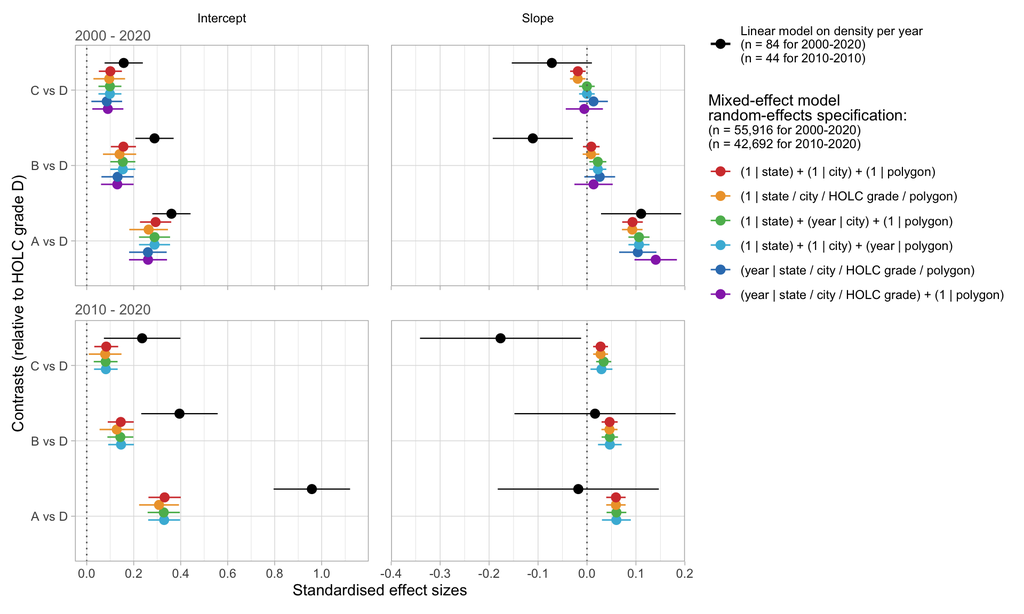

```r
  add_02_break  <- function(lims) sort(unique(c(scales::pretty_breaks()(lims), 0.2)))

  facet_scales <- lapply(seq_len(nrow(rng)), function(i) {
    tl <- rng$type2[i]
    lo <- rng$xmin[i]
    hi <- rng$xmax[i]

    if (grepl("^Slope", tl)) {
      rlang::new_formula(
        lhs = bquote(type2 == .(tl)),
        rhs = scale_x_continuous(
          limits = c(-0.4, 0.2),
          breaks = add_02_break,
          oob = scales::oob_keep, # keep data for stats, don't drop rows
          expand = expansion(mult = c(0, 0))
        )
      )
    } else if (grepl("^Intercept", tl)) {
      rlang::new_formula(
        lhs = bquote(type2 == .(tl)),
        rhs = scale_x_continuous(
          limits = c(-0.05, 1.2),
          breaks = add_02_break,
          oob = scales::oob_keep,
          expand = expansion(mult = c(0, 0))
        )
      )
    } else {
      rlang::new_formula(
        lhs = bquote(type2 == .(tl)),
        rhs = scale_x_continuous(
          limits = c(lo, hi),
          oob = scales::oob_keep,
          expand = expansion(mult = c(0, 0))
        )
      )
    }
  })

  tr1D_adj <- tr1D + ggh4x::facetted_pos_scales(x = facet_scales)
  tr2D_adj <- tr2D + ggh4x::facetted_pos_scales(x = facet_scales)

  (tr1D_adj / tr2D_adj) + plot_layout(axis_titles = "collect") #; ggsave('Output/rev_Fig_Z1_yr-trend_model-compar_D_standardised.png', width= 25, height = 15, units ='cm')
```

**Figure Z1** | Change in HOLC grade sampling density over time. Dots represent differences (in mean values or slopes) relative to HOLC grade D (for actual values see Fig. Z2), specifically standard deviations of ln-scaled sampling density (Intercepts) per standard deviation of year (slopes). Horizontal lines indicate 95% confidence intervals, colour a random-effect model structure (with variables left from `|` indicating random slopes and right from `|` indicating random intercepts, whereas ‘/’ indicates nested intercepts). Top row contains estimates for a dataset spanning from 2000 until 2020 (n = 55,916 polygons with known area) and bottom row for a dataset from 2010 until 2020 (n = 42,692).